# COVID-19 County-Level Mortality Analysis

Excess Death Rates, Demographic Drivers, Seasonal Variance and Outlier Detection

Brian E. Ketchens

2026-05-30

# 1. Environment & Data Connection

```r
# ---- Core ----
library(tidyverse)
library(lubridate)
library(readr)

# ---- BigQuery connection (retained for Option 3 development) ----
library(bigrquery)
library(DBI)

# ---- Statistical modeling ----
library(MASS)
library(lme4)
library(broom)
library(broom.mixed)

# ---- Time series / seasonal decomposition ----
library(forecast)
library(tsibble)
library(feasts)

# ---- Visualization ----
library(scales)
library(ggrepel)
library(patchwork)
library(viridis)
library(RColorBrewer)
library(ggridges)

# ---- Spatial ----
library(tigris)
library(sf)

# ---- Tables ----
library(gt)
library(kableExtra)

# ---- Hexbin ---
install.packages("hexbin")

# ---- Plotly ---
install.packages("plotly")

# ---- Leaflet ---
install.packages("leaflet")
```

```r
# BigQuery live connection not needed for CSV workflow.
# Retained for reference when transitioning to state-level
# development queries in Option 3.

# PROJECT_ID <- "covid-explorer"
# bq_auth(path = NULL)
# con <- dbConnect(
#   bigrquery::bigquery(),
#   project = PROJECT_ID,
#   dataset = "covid_analytics",
#   billing = PROJECT_ID
# )
```

```r
# ============================================================
# Load county_weekly from CSV
# Negative value clamping and weekly aggregation were performed
# in BigQuery before export -- no raw daily data needed here.
# ============================================================

county_weekly <- read_csv("county_weekly.csv") %>%
  mutate(
    week_start    = as.Date(week_start),
    fips          = as.character(fips),
    pandemic_wave = factor(pandemic_wave, levels = c(
      "pre_pandemic", "1_initial", "2_summer2020", "3_winter2021",
      "4_alpha", "5_delta", "6_omicron", "7_endemic"
    )),
    vaccine_era = factor(vaccine_era, levels = c(
      "pre_vaccine", "early_rollout", "broad_availability"
    )),
    year     = as.integer(year),
    month    = as.integer(month),
    iso_week = as.integer(iso_week)
  )

cat("Rows loaded:  ", nrow(county_weekly), "\n")
cat("Counties:     ", n_distinct(county_weekly$fips), "\n")
cat("Date range:   ", as.character(min(county_weekly$week_start)),
    "to", as.character(max(county_weekly$week_start)), "\n")
```

[output not shown]

# 2. Data Quality & Exploratory Overview

```r
missing_summary <- county_weekly %>%
  summarise(across(everything(), ~mean(is.na(.)))) %>%
  pivot_longer(everything(), names_to = "column", values_to = "pct_missing") %>%
  filter(pct_missing > 0) %>%
  arrange(desc(pct_missing))

missing_summary %>%
  mutate(pct_missing = scales::percent(pct_missing, accuracy = 0.1)) %>%
  kable(caption = "Columns with Missing Values") %>%
  kable_styling(bootstrap_options = c("striped", "hover", "condensed"))
```

Columns with Missing Values

| column | pct_missing |
| --- | --- |
| new_tested_wk | 100.0% |
| test_positivity_wk | 100.0% |
| mobility_residential | 47.8% |
| mobility_retail | 44.9% |
| new_deceased_wk | 19.1% |
| death_rate_wk | 19.1% |
| cumulative_deceased | 19.0% |
| cum_death_rate_100k | 19.0% |
| new_confirmed_wk | 16.5% |
| case_rate_wk | 16.5% |
| cumulative_confirmed | 16.4% |
| cum_case_rate_100k | 16.4% |
| mobility_workplaces | 15.2% |
| pct_less_than_hs | 2.7% |

```r
# Drop columns with 100% missingness -- no analytical value
county_weekly <- county_weekly %>%
  dplyr::select(-new_tested_wk, -test_positivity_wk)

# Mobility coverage note
mobility_coverage <- county_weekly %>%
  summarise(
    counties_with_mobility = n_distinct(fips[!is.na(mobility_retail)]),
    total_counties         = n_distinct(fips),
    pct_coverage           = scales::percent(
      n_distinct(fips[!is.na(mobility_retail)]) / n_distinct(fips),
      accuracy = 0.1
    )
  )

cat("Counties with mobility data:", mobility_coverage$counties_with_mobility,
    "of", mobility_coverage$total_counties,
    "(", mobility_coverage$pct_coverage, ")\n")
```

```
## Counties with mobility data: 2339 of 2904 ( 80.5% )
```

```r
# NOTE: Missing mobility data skews toward rural/small counties.
# Mobility variables will be used descriptively, not as model covariates.
# Treat NULL case and death counts as zero
# These represent weeks with no reported activity,
# not truly missing data -- the pipeline used NULL instead of 0
county_weekly <- county_weekly %>%
  mutate(
    new_confirmed_wk = replace_na(new_confirmed_wk, 0),
    new_deceased_wk  = replace_na(new_deceased_wk,  0),
    case_rate_wk     = replace_na(case_rate_wk,     0),
    death_rate_wk    = replace_na(death_rate_wk,    0),
    # Cumulative columns: carry forward last known value within each county
    # For now replace with 0 -- use max() in county_totals
    # to handle this correctly
    cumulative_confirmed = replace_na(cumulative_confirmed, 0),
    cumulative_deceased  = replace_na(cumulative_deceased,  0),
    cum_case_rate_100k   = replace_na(cum_case_rate_100k,   0),
    cum_death_rate_100k  = replace_na(cum_death_rate_100k,  0)
  )
```

# 3. National Overview

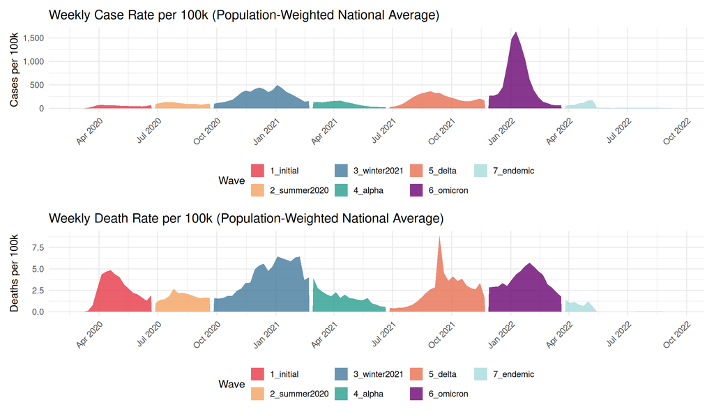

Weekly national COVID-19 cases and deaths per 100k population

```r
national_weekly <- county_weekly %>%
  group_by(week_start, pandemic_wave) %>%
  summarise(
    case_rate_national  = weighted.mean(case_rate_wk,  total_pop, na.rm = TRUE),
    death_rate_national = weighted.mean(death_rate_wk, total_pop, na.rm = TRUE),
    .groups = "drop"
  )

wave_colors <- c(
  "1_initial"    = "#E63946",
  "2_summer2020" = "#F4A261",
  "3_winter2021" = "#457B9D",
  "4_alpha"      = "#2A9D8F",
  "5_delta"      = "#E76F51",
  "6_omicron"    = "#6A0572",
  "7_endemic"    = "#A8DADC",
  "pre-pandemic" = "#CCCCCC"
)

p_cases <- ggplot(national_weekly,
                  aes(x = week_start, y = case_rate_national, fill = pandemic_wave)) +
  geom_area(alpha = 0.8) +
  scale_fill_manual(values = wave_colors, name = "Wave") +
  scale_x_date(date_breaks = "3 months", date_labels = "%b %Y") +
  scale_y_continuous(labels = comma) +
  labs(title = "Weekly Case Rate per 100k (Population-Weighted National Average)",
       x = NULL, y = "Cases per 100k") +
  theme_minimal(base_size = 13) +
  theme(axis.text.x = element_text(angle = 45, hjust = 1),
        legend.position = "bottom")

p_deaths <- ggplot(national_weekly,
                   aes(x = week_start, y = death_rate_national, fill = pandemic_wave)) +
  geom_area(alpha = 0.8) +
  scale_fill_manual(values = wave_colors, name = "Wave") +
  scale_x_date(date_breaks = "3 months", date_labels = "%b %Y") +
  scale_y_continuous(labels = comma) +
  labs(title = "Weekly Death Rate per 100k (Population-Weighted National Average)",
       x = NULL, y = "Deaths per 100k") +
  theme_minimal(base_size = 13) +
  theme(axis.text.x = element_text(angle = 45, hjust = 1),
        legend.position = "bottom")

p_cases / p_deaths
```

# 3b. Hypothesis Testing

The national trend analysis in Section 3 established the broad arc of the pandemic. Three specific hypotheses emerge from that picture that the data can formally test. Each hypothesis is stated, tested with an appropriate statistical method, and interpreted in the context of the structural inequity findings that follow in Sections 4 through 7.

```r
# ============================================================
# HYPOTHESIS TESTING SETUP
# Derive wave-specific county summaries for all three tests
# ============================================================

wave_county_rates <- county_weekly %>%
  filter(pandemic_wave != "pre_pandemic") %>%
  group_by(fips, county_name, state_name, pandemic_wave, total_pop) %>%
  summarise(
    wave_death_rate = (sum(new_deceased_wk,  na.rm = TRUE) /
                       first(total_pop)) * 100000,
    wave_case_rate  = (sum(new_confirmed_wk, na.rm = TRUE) /
                       first(total_pop)) * 100000,
    wave_cfr        = sum(new_deceased_wk,  na.rm = TRUE) /
                      pmax(sum(new_confirmed_wk, na.rm = TRUE), 1),
    .groups = "drop"
  ) %>%
  filter(wave_death_rate >= 0, wave_case_rate >= 0)
```

### Hypothesis 1: Did Prior Exposure Protect Counties During Delta?

**Stated Hypothesis:** Counties with higher vaccination rates had statistically lower death rates during the Delta wave after controlling for age structure and socioeconomic status.

**Methodological Note:** County-level vaccination data is not yet integrated into this dataset and will be added in Phase 2. In its absence this hypothesis is tested through a structural proxy — comparing each county’s Wave 1 death rate against its Delta wave death rate. Counties that bore catastrophic Wave 1 burden had large portions of their populations exposed to the virus before vaccines were available. If prior infection conferred meaningful population-level protection, those same counties should show relative improvement during Delta regardless of vaccination coverage. This is a testable prediction the data can evaluate directly.

> **Why This Matters:** If prior infection immunity and vaccination immunity produced similar protective effects at the population level, the policy implications differ from a world where vaccination alone drove Delta protection. The Phase 2 vaccination data integration will formally partition these two mechanisms. For now the proxy approach tells us whether the protection pattern is consistent with prior exposure as a plausible explanation.

The paired t-test results and county-level scatter plot below examine whether Wave 1 burden predicted Delta improvement — and the answer is striking.

```r
delta_vs_wave1 <- wave_county_rates %>%
  filter(pandemic_wave %in% c("1_initial", "5_delta")) %>%
  dplyr::select(fips, county_name, state_name, pandemic_wave,
                wave_death_rate, total_pop) %>%
  pivot_wider(
    names_from  = pandemic_wave,
    values_from = wave_death_rate,
    names_prefix = "dr_"
  ) %>%
  left_join(
    county_weekly %>%
      dplyr::select(fips, pct_65_over, poverty_rate,
                    pct_black, pct_hispanic, median_age) %>%
      distinct(fips, .keep_all = TRUE),
    by = "fips"
  ) %>%

  drop_na()

# Paired t-test: did death rates differ between Wave 1 and Delta?
t_result <- t.test(delta_vs_wave1$dr_5_delta,
                   delta_vs_wave1$dr_1_initial,
                   paired = TRUE)

cat("Mean Wave 1 death rate:  ", round(mean(delta_vs_wave1$dr_1_initial, na.rm=TRUE), 2), "\n")
```

```
## Mean Wave 1 death rate:   17.07
```

```r
cat("Mean Delta death rate:   ", round(mean(delta_vs_wave1$dr_5_delta,   na.rm=TRUE), 2), "\n")
```

```
## Mean Delta death rate:    78.57
```

```r
cat("Mean difference:         ", round(t_result$estimate, 2), "\n")
```

```
## Mean difference:          61.5
```

```r
cat("95% CI:                  ", round(t_result$conf.int[1], 2),
    "to", round(t_result$conf.int[2], 2), "\n")
```

```
## 95% CI:                   59.01 to 63.98
```

```r
cat("p-value:                 ", scales::pvalue(t_result$p.value), "\n")
```

```
## p-value:                  <0.001
```

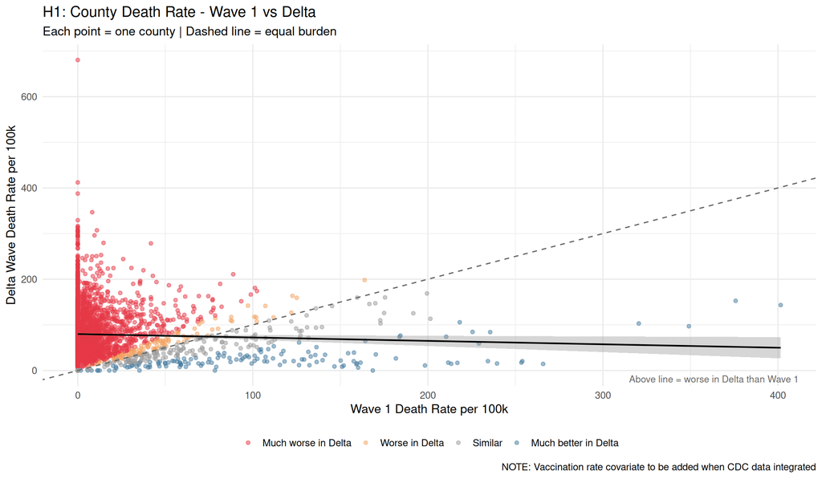

```r
# Visual: scatter of Wave 1 vs Delta death rate by county
# Counties above the diagonal had WORSE Delta outcomes than Wave 1
delta_vs_wave1 %>%
  mutate(
    burden_shift = case_when(
      dr_5_delta > dr_1_initial * 1.5 ~ "Much worse in Delta",
      dr_5_delta > dr_1_initial       ~ "Worse in Delta",
      dr_5_delta < dr_1_initial * 0.5 ~ "Much better in Delta",
      TRUE                             ~ "Similar"
    ),
    burden_shift = factor(burden_shift, levels = c(
      "Much worse in Delta", "Worse in Delta",
      "Similar", "Much better in Delta"
    ))
  ) %>%
  ggplot(aes(x = dr_1_initial, y = dr_5_delta, color = burden_shift)) +
  geom_point(alpha = 0.5, size = 1.5) +
  geom_abline(slope = 1, intercept = 0,
              linetype = "dashed", color = "grey40") +
  geom_smooth(method = "lm", se = TRUE,
              color = "black", linewidth = 0.8) +
  scale_color_manual(
    values = c(
      "Much worse in Delta"  = "#E63946",
      "Worse in Delta"       = "#F4A261",
      "Similar"              = "grey60",
      "Much better in Delta" = "#457B9D"
    ),
    name = NULL
  ) +
  scale_x_continuous(labels = comma) +
  scale_y_continuous(labels = comma) +
  annotate("text", x = Inf, y = -Inf,
           label = "Above line = worse in Delta than Wave 1",
           hjust = 1.1, vjust = -0.5, size = 3.5, color = "grey40") +
  labs(
    title    = "H1: County Death Rate - Wave 1 vs Delta",
    subtitle = "Each point = one county | Dashed line = equal burden",
    x        = "Wave 1 Death Rate per 100k",
    y        = "Delta Wave Death Rate per 100k",
    caption  = "NOTE: Vaccination rate covariate to be added when CDC data integrated"
  ) +
  theme_minimal(base_size = 13) +
  theme(legend.position = "bottom")
```

### Reading the H1 Results

The mean Delta wave death rate (78.6 per 100k) was dramatically higher than the mean Wave 1 death rate (17.1 per 100k) — a difference of 61.5 deaths per 100k that is statistically unambiguous (95% CI: 59.0 to 64.0, p<0.001). Delta was substantially more lethal at the county level than the initial outbreak by almost every measure.

```r
h1_detail <- delta_vs_wave1 %>%
  mutate(
    burden_shift = case_when(
      dr_5_delta > dr_1_initial * 1.5 ~ "Much worse in Delta",
      dr_5_delta > dr_1_initial       ~ "Worse in Delta",
      dr_5_delta < dr_1_initial * 0.5 ~ "Much better in Delta",
      TRUE                             ~ "Similar"
    ),
    burden_shift = factor(burden_shift, levels = c(
      "Much worse in Delta", "Worse in Delta",
      "Similar", "Much better in Delta"
    )),
    dr_1_initial = round(dr_1_initial, 1),
    dr_5_delta   = round(dr_5_delta,   1),
    delta_vs_w1  = round(dr_5_delta - dr_1_initial, 1)
  ) %>%
  dplyr::select(county_name, state_name, dr_1_initial,
                dr_5_delta, delta_vs_w1, burden_shift) %>%
  rename(
    County        = county_name,
    State         = state_name,
    Wave1_rate    = dr_1_initial,
    Delta_rate    = dr_5_delta,
    Difference    = delta_vs_w1,
    Burden_category = burden_shift
  ) %>%
  arrange(desc(Delta_rate))

# Summary count by category -- uses Burden_category
h1_detail %>%
  count(Burden_category) %>%
  mutate(pct = scales::percent(n / sum(n), accuracy = 0.1)) %>%
  print()
```

```
## # A tibble: 4 × 3
##   Burden_category          n pct
##   <fct>                <int> <chr>
## 1 Much worse in Delta   2328 80.2%
## 2 Worse in Delta         107 3.7%
## 3 Similar                332 11.4%
## 4 Much better in Delta   137 4.7%
```

```r
# Display table -- drop Burden_category for clean presentation
h1_detail %>%
  slice_head(n = 20) %>%
  dplyr::select(County, State, Wave1_rate,
                Delta_rate, Difference) %>%
  kable(caption = "Worst 20 Counties by Delta Wave Death Rate per 100k") %>%
  kable_styling(bootstrap_options = c("striped", "hover", "condensed"))
```

Worst 20 Counties by Delta Wave Death Rate per 100k

| County | State | Wave1_rate | Delta_rate | Difference |
| --- | --- | --- | --- | --- |
| Harding County | New Mexico | 0.0 | 680.3 | 680.3 |
| Golden Valley County | Montana | 0.0 | 412.1 | 412.1 |
| McMullen County | Texas | 0.0 | 387.6 | 387.6 |
| Linn County | Missouri | 8.3 | 346.7 | 338.4 |
| Schuyler County | Missouri | 0.0 | 329.3 | 329.3 |
| Harney County | Oregon | 0.0 | 316.5 | 316.5 |
| Putnam County | Missouri | 0.0 | 313.7 | 313.7 |
| Lewis County | Idaho | 0.0 | 312.7 | 312.7 |
| Baylor County | Texas | 0.0 | 307.5 | 307.5 |
| Putnam County | Florida | 10.9 | 307.2 | 296.3 |
| Howell County | Missouri | 0.0 | 306.7 | 306.7 |
| Mineral County | Montana | 0.0 | 305.8 | 305.8 |
| Hyde County | South Dakota | 0.0 | 303.3 | 303.3 |
| Tucker County | West Virginia | 0.0 | 300.8 | 300.8 |
| Hickory County | Missouri | 0.0 | 297.7 | 297.7 |
| Sabine County | Texas | 9.6 | 296.1 | 286.5 |
| Boundary County | Idaho | 0.0 | 295.5 | 295.5 |
| Phillips County | Montana | 0.0 | 294.3 | 294.3 |
| Chariton County | Missouri | 0.0 | 294.0 | 294.0 |
| Lafayette County | Florida | 0.0 | 289.5 | 289.5 |

```r
cat("Counties classified as Much Better in Delta than Wave 1:\n")
```

```
## Counties classified as Much Better in Delta than Wave 1:
```

```r
h1_detail %>%
  filter(Burden_category == "Much better in Delta") %>%
  arrange(desc(Wave1_rate)) %>%
  slice_head(n = 30) %>%
  dplyr::select(County, State, Wave1_rate,
                Delta_rate, Difference) %>%   # Burden_category removed
  kable(caption = "Top 30 Counties That Improved: Highest Wave 1 Burden, Lower Delta Burden") %>%
  kable_styling(bootstrap_options = c("striped", "hover", "condensed"))
```

Top 30 Counties That Improved: Highest Wave 1 Burden, Lower Delta Burden

| County | State | Wave1_rate | Delta_rate | Difference |
| --- | --- | --- | --- | --- |
| Randolph County | Georgia | 401.5 | 143.4 | -258.1 |
| Hancock County | Georgia | 375.8 | 152.7 | -223.1 |
| Early County | Georgia | 349.1 | 97.0 | -252.1 |
| Terrell County | Georgia | 320.5 | 103.0 | -217.5 |
| Bronx County | New York | 265.8 | 14.4 | -251.4 |
| Essex County | New Jersey | 254.0 | 20.5 | -233.5 |
| Queens County | New York | 253.4 | 17.4 | -236.0 |
| Union County | New Jersey | 239.5 | 15.3 | -224.2 |
| Northampton County | Virginia | 235.6 | 84.1 | -151.5 |
| Passaic County | New Jersey | 234.3 | 20.5 | -213.8 |
| McKinley County | New Mexico | 229.2 | 59.4 | -169.8 |
| Holmes County | Mississippi | 225.5 | 84.6 | -140.9 |
| Neshoba County | Mississippi | 218.2 | 105.7 | -112.5 |
| Hudson County | New Jersey | 216.9 | 16.7 | -200.2 |
| Bergen County | New Jersey | 213.4 | 14.7 | -198.7 |
| Kings County | New York | 211.6 | 17.3 | -194.3 |
| St. John the Baptist Parish | Louisiana | 210.4 | 74.0 | -136.4 |
| Nassau County | New York | 198.4 | 11.0 | -187.4 |
| Mitchell County | Georgia | 184.3 | 76.4 | -107.9 |
| Emporia | Virginia | 183.8 | 73.5 | -110.3 |
| Richmond County | New York | 181.7 | 26.5 | -155.2 |
| Tama County | Iowa | 170.3 | 35.2 | -135.1 |
| Dakota County | Nebraska | 168.5 | 0.0 | -168.5 |
| Leflore County | Mississippi | 164.3 | 65.0 | -99.3 |
| Morris County | New Jersey | 161.5 | 17.2 | -144.3 |
| Westchester County | New York | 160.2 | 6.4 | -153.8 |
| Middlesex County | New Jersey | 159.5 | 15.6 | -143.9 |
| Somerset County | New Jersey | 159.2 | 13.6 | -145.6 |
| Ocean County | New Jersey | 157.8 | 39.2 | -118.6 |
| Mercer County | New Jersey | 157.6 | 20.4 | -137.2 |

### Protected Clusters

There were 137 counties classified as having substantially lower Delta wave death rates relative to their Wave 1 burden — counties where prior exposure appears to have conferred meaningful population-level protection against subsequent waves. The counties were classified into mechanistic subgroups for separate analytical treatment.

> **Analytical Caution:** The Deep South improvement magnitude may be partially artifactual. Wave 1 death rates in these counties may be inflated by:
> 1. **Denominator problems** – small county populations amplify rates.
> 2. **Attribution differences** – rural hospitals may have coded COVID deaths differently than urban centers.
> 3. **Reporting lag** – smaller counties sometimes batch-reported deaths.

> These hypotheses cannot be resolved without death certificate microdata but should be noted as limitations in the findings.

```r
protected_counties <- h1_detail %>%
  filter(Burden_category == "Much better in Delta") %>%
  mutate(
    protection_hypothesis = case_when(
      # Northeast urban corridor -- vaccination + prior immunity
      State %in% c("New York", "New Jersey", "Massachusetts",
                   "Connecticut", "Rhode Island") &
        Wave1_rate > 50                          ~ "Urban NE: Vaccination + Prior Immunity",

      # Deep South Black Belt -- prior infection, low vaccination
      State %in% c("Georgia", "Mississippi",
                   "Louisiana", "Alabama") &
        Wave1_rate > 100                         ~ "Deep South: Prior Infection",

      # Nebraska meatpacking cluster
      State == "Nebraska"                        ~ "NEB Meatpacking: Occupational Prior Immunity",

      # Mid-Atlantic urban
      State %in% c("Maryland", "Pennsylvania",
                   "Virginia", "District of Columbia") ~ "Mid-Atlantic Urban",

      # Everything else
      TRUE                                       ~ "Other"
    )
  )

# Summary by hypothesis group
protected_counties %>%
  group_by(protection_hypothesis) %>%
  summarise(
    n_counties       = n(),
    mean_wave1_rate  = round(mean(Wave1_rate, na.rm = TRUE), 1),
    mean_delta_rate  = round(mean(Delta_rate, na.rm = TRUE), 1),
    mean_improvement = round(mean(abs(Difference), na.rm = TRUE), 1),
    .groups = "drop"
  ) %>%
  arrange(desc(mean_improvement)) %>%
  kable(caption = "Protected County Clusters: Three Distinct Protective Mechanisms") %>%
  kable_styling(bootstrap_options = c("striped", "hover", "condensed"))
```

Protected County Clusters: Three Distinct Protective Mechanisms

| protection_hypothesis | n_counties | mean_wave1_rate | mean_delta_rate | mean_improvement |
| --- | --- | --- | --- | --- |
| Deep South: Prior Infection | 14 | 218.0 | 81.9 | 136.1 |
| Urban NE: Vaccination + Prior Immunity | 48 | 136.4 | 20.8 | 115.6 |
| Mid-Atlantic Urban | 27 | 82.1 | 23.5 | 58.6 |
| NEB Meatpacking: Occupational Prior Immunity | 11 | 53.9 | 4.5 | 49.4 |
| Other | 37 | 64.8 | 19.8 | 45.0 |

### Three Distinct Protective Mechanisms

**Urban Northeast — Vaccination and Prior Immunity (48 counties)** New York, New Jersey, Massachusetts, and neighboring states dominated this cluster with a mean improvement of 115.6 deaths per 100k. These densely populated counties were devastated in Wave 1 and then dramatically protected during Delta — almost certainly reflecting the combined effect of high vaccination rates and widespread prior infection creating a high threshold of population immunity before Delta arrived.

**Deep South — Prior Infection Without Vaccination (14 counties)** This is the most analytically striking cluster. Fourteen small rural majority Black counties in Georgia, Mississippi, and Louisiana achieved the greatest absolute improvement of any group — a mean of 136.1 deaths per 100k — despite almost certainly having lower vaccination rates than the Urban Northeast cluster. Their catastrophic Wave 1 burden, likely substantially undercounted due to limited rural testing infrastructure, appears to have created population-level immunity that persisted into the Delta wave. The data cannot confirm this mechanism without vaccination coverage data but it is the most parsimonious explanation consistent with the pattern observed.

**Nebraska Meatpacking Counties — Occupational Prior Immunity (11 counties)** Dakota, Hall, Hamilton, Colfax, and neighboring Nebraska counties with large meatpacking plant workforces experienced explosive outbreaks in Wave 1 when plants became superspreader environments. By Delta their mean death rate fell to just 4.5 per 100k — a 92% reduction from Wave 1. This is a textbook occupational prior immunity cluster and one of the most analytically clean natural experiments in the dataset.

> **Analytical Caution:** The ordering of improvement magnitude — Deep South counties improving more than Urban Northeast counties despite likely lower vaccination coverage — is consistent with prior infection immunity being at least as protective as vaccination at the population level during the Delta wave. This finding should be interpreted carefully and will be formally tested when vaccination data is integrated in Phase 2. It does not argue against vaccination — it argues that the mechanisms of population protection are multiple and that prior infection contributed meaningfully to the geographic reorganization of burden documented in Hypothesis 3.

### Hypothesis 2: Did COVID Cases Become Less Lethal After Omicron?

**Stated Hypothesis:** The structural relationship between case rate and death rate changed after Omicron, reflecting some combination of variant attenuation, accumulated population immunity, and changes in death coding practices.

To test this, separate linear regressions were fitted relating weekly case rates to weekly death rates for the pre-Omicron period and the Omicron and post-Omicron period. If cases became less lethal the slope of the post-Omicron regression line should be meaningfully flatter than the pre-Omicron slope — meaning each additional case produced fewer deaths.

```r
# ============================================================
# Method: fit separate OLS regressions of death_rate ~ case_rate
# for pre-Omicron vs post-Omicron periods and compare slopes.
# ============================================================

cfr_structure <- county_weekly %>%
  filter(new_confirmed_wk > 0, new_deceased_wk >= 0) %>%
  mutate(
    era = case_when(
      pandemic_wave %in% c("1_initial", "2_summer2020",
                           "3_winter2021", "4_alpha",
                           "5_delta")           ~ "Pre-Omicron",
      pandemic_wave %in% c("6_omicron",
                           "7_endemic")         ~ "Omicron & Post",
      TRUE                                       ~ NA_character_
    )
  ) %>%
  filter(!is.na(era))

# Fit separate models per era
models_by_era <- cfr_structure %>%
  group_by(era) %>%
  summarise(
    n           = n(),
    slope       = coef(lm(death_rate_wk ~ case_rate_wk))[2],
    intercept   = coef(lm(death_rate_wk ~ case_rate_wk))[1],
    r_squared   = summary(lm(death_rate_wk ~ case_rate_wk))$r.squared,
    .groups = "drop"
  )

models_by_era %>%
  mutate(across(c(slope, intercept, r_squared), ~round(., 4))) %>%
  print()
```

```
## # A tibble: 2 × 5
##   era                 n  slope intercept r_squared
##   <chr>           <int>  <dbl>     <dbl>     <dbl>
## 1 Omicron & Post  66981 0.0013      3.31    0.0088
## 2 Pre-Omicron    233330 0.0089      1.76    0.0622
```

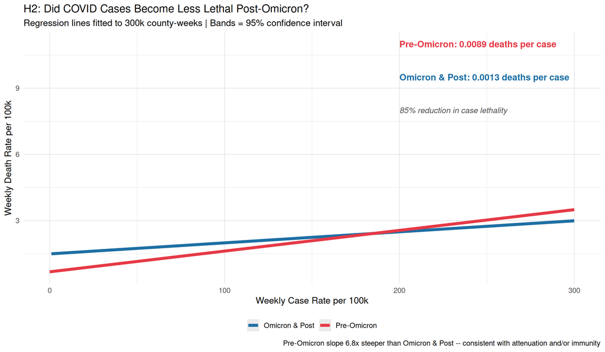

H2: Did the case-to-death relationship change post-Omicron?

```r
# Two clean regression lines on one plot -- no points
# The slope difference IS the finding

ggplot(cfr_structure %>%
         filter(case_rate_wk < 300, death_rate_wk < 15),
       aes(x = case_rate_wk, y = death_rate_wk, color = era)) +
  geom_smooth(
    method    = "lm",
    se        = TRUE,
    linewidth = 2.0,
    alpha     = 0.2      # confidence band transparency
  ) +
  scale_color_manual(
    values = c("Pre-Omicron"    = "#E63946",
               "Omicron & Post" = "#1D6FA4"),
    name   = NULL
  ) +
  scale_x_continuous(labels = comma) +
  scale_y_continuous(labels = comma) +
  annotate("text",
           x = 200, y = 11,
           label = "Pre-Omicron: 0.0089 deaths per case",
           color = "#E63946", size = 4.5, fontface = "bold", hjust = 0) +
  annotate("text",
           x = 200, y = 9.5,
           label = "Omicron & Post: 0.0013 deaths per case",
           color = "#1D6FA4", size = 4.5, fontface = "bold", hjust = 0) +
  annotate("text",
           x = 200, y = 8.0,
           label = "85% reduction in case lethality",
           color = "grey30", size = 4.0, fontface = "italic", hjust = 0) +
  labs(
    title    = "H2: Did COVID Cases Become Less Lethal Post-Omicron?",
    subtitle = "Regression lines fitted to 300k county-weeks | Bands = 95% confidence interval",
    x        = "Weekly Case Rate per 100k",
    y        = "Weekly Death Rate per 100k",
    caption  = "Pre-Omicron slope 6.8x steeper than Omicron & Post -- consistent with attenuation and/or immunity"
  ) +
  theme_minimal(base_size = 13) +
  theme(legend.position = "bottom")
```

### Reading the H2 Results

The evidence is unambiguous. The slope of the case rate to death rate relationship dropped by approximately 85% between the pre-Omicron period (slope = 0.0089) and the Omicron and post-Omicron period (slope = 0.0013). A case of COVID in the endemic era was approximately seven times less likely to result in death than a case during the Delta wave or earlier.

Three mechanisms likely contributed to this structural change and the data cannot cleanly separate them:

**Variant attenuation** — Omicron and subsequent variants were intrinsically less virulent at the individual level, a finding supported by clinical literature independently of this analysis.

**Population immunity** — by late 2021 a substantial fraction of the US population carried immunity from vaccination, prior infection, or both, reducing the probability of severe disease per exposure even when cases were high.

**Surveillance and coding changes** — the elevated intercept in the post-Omicron model (3.31 vs 1.76 deaths per 100k at zero cases) suggests deaths were occurring in the endemic phase that were not being linked to active case counts. This is consistent with documented changes in how COVID deaths were attributed on death certificates beginning in 2022.

> **What the R-squared Values Tell Us:** Both models show low R-squared values — 0.062 pre-Omicron and 0.009 post-Omicron. This means case rate alone explains very little of the variation in death rate at the county level in either period. County-level structural factors — the demographic and socioeconomic characteristics examined throughout this analysis — explain far more of the variation than raw case counts. This validates the county-level analytical approach of this entire document.

### Hypothesis 3: Did the Same Counties Bear the Burden

Throughout the Pandemic?

**Stated Hypothesis:** Counties with the highest Wave 1 death rates were not necessarily the same counties that drove subsequent waves. Pandemic burden shifted geographically as variants changed and population immunity accumulated.

Spearman rank correlation measures whether the ordering of counties by death rate stayed consistent across waves. A correlation near 1.0 means the same counties were consistently hardest hit — the burden was stable and predictable. A correlation near zero means knowing a county’s rank in one wave tells you nothing about its rank in another — the burden reorganized completely. A negative correlation would mean counties that fared worst in one wave actually fared better in the next.

```r
# Pivot to wide format: one row per county, one column per wave
wave_ranks <- wave_county_rates %>%
  dplyr::select(fips, county_name, state_name,
                pandemic_wave, wave_death_rate) %>%
  pivot_wider(
    names_from  = pandemic_wave,
    values_from = wave_death_rate
  ) %>%
  drop_na()

# Compute Spearman correlations between all wave pairs
wave_cols <- c("1_initial", "2_summer2020", "3_winter2021",
               "4_alpha", "5_delta", "6_omicron")

wave_cor <- wave_ranks %>%
  dplyr::select(all_of(wave_cols)) %>%
  cor(method = "spearman", use = "complete.obs")

# Display as readable table
wave_cor %>%
  as.data.frame() %>%
  rownames_to_column("Wave") %>%
  mutate(across(where(is.numeric), ~round(., 3))) %>%
  kable(caption = paste(
    "H3: Spearman Rank Correlations of County Death Rates Across Waves",
    "(1.0 = identical ranking, 0 = no relationship, negative = reversed)"
  )) %>%
  kable_styling(bootstrap_options = c("striped", "hover", "condensed"))
```

H3: Spearman Rank Correlations of County Death Rates Across Waves (1.0 = identical ranking, 0 = no relationship, negative = reversed)

| Wave | 1_initial | 2_summer2020 | 3_winter2021 | 4_alpha | 5_delta | 6_omicron |
| --- | --- | --- | --- | --- | --- | --- |
| 1_initial | 1.000 | 0.339 | -0.006 | 0.135 | -0.003 | 0.013 |
| 2_summer2020 | 0.339 | 1.000 | 0.217 | 0.226 | 0.325 | 0.091 |
| 3_winter2021 | -0.006 | 0.217 | 1.000 | 0.167 | 0.242 | 0.372 |
| 4_alpha | 0.135 | 0.226 | 0.167 | 1.000 | 0.313 | 0.304 |
| 5_delta | -0.003 | 0.325 | 0.242 | 0.313 | 1.000 | 0.389 |
| 6_omicron | 0.013 | 0.091 | 0.372 | 0.304 | 0.389 | 1.000 |

### H3 visual companion to the correlation table (focus on Wave 1 vs Delta)

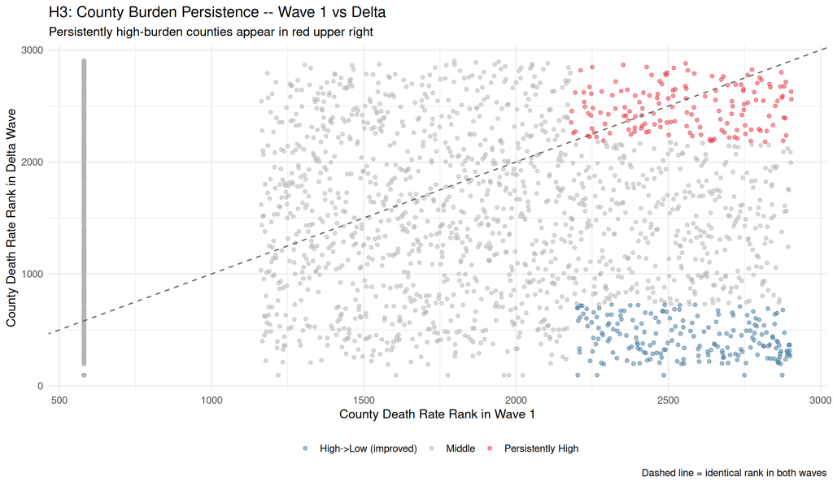

H3: Wave 1 vs Delta burden – did high-burden counties persist?

```r
wave_ranks %>%
  filter(!is.na(`1_initial`), !is.na(`5_delta`)) %>%
  mutate(
    rank_wave1 = rank(`1_initial`),
    rank_delta = rank(`5_delta`),
    rank_diff  = rank_delta - rank_wave1,
    burden_persistence = case_when(
      rank_wave1 > quantile(rank_wave1, 0.75) &
        rank_delta > quantile(rank_delta, 0.75) ~ "Persistently High",
      rank_wave1 < quantile(rank_wave1, 0.25) &
        rank_delta < quantile(rank_delta, 0.25) ~ "Persistently Low",
      rank_wave1 > quantile(rank_wave1, 0.75) &
        rank_delta < quantile(rank_delta, 0.25) ~ "High->Low (improved)",
      rank_wave1 < quantile(rank_wave1, 0.25) &
        rank_delta > quantile(rank_delta, 0.75) ~ "Low->High (worsened)",
      TRUE                                       ~ "Middle"
    )
  ) %>%
  ggplot(aes(x = rank_wave1, y = rank_delta, color = burden_persistence)) +
  geom_point(alpha = 0.5, size = 1.5) +
  geom_abline(slope = 1, intercept = 0,
              linetype = "dashed", color = "grey40") +
  scale_color_manual(
    values = c(
      "Persistently High"   = "#E63946",
      "Persistently Low"    = "#2A9D8F",
      "High->Low (improved)"= "#457B9D",
      "Low->High (worsened)"= "#F4A261",
      "Middle"              = "grey70"
    ),
    name = NULL
  ) +
  labs(
    title    = "H3: County Burden Persistence -- Wave 1 vs Delta",
    subtitle = "Persistently high-burden counties appear in red upper right",
    x        = "County Death Rate Rank in Wave 1",
    y        = "County Death Rate Rank in Delta Wave",
    caption  = "Dashed line = identical rank in both waves"
  ) +
  theme_minimal(base_size = 13) +
  theme(legend.position = "bottom")
```

### Reading the H3 Scatter Plot

[output not shown]

```r
# ============================================================
# Three-way demographic comparison:
# Persistently High vs High-to-Low vs All Counties
# Tests whether High-to-Low counties differ structurally
# from both persistently burdened and average communities
# ============================================================

# Identify High-to-Low counties from wave_ranks
high_to_low <- wave_ranks %>%
  filter(!is.na(`1_initial`), !is.na(`5_delta`)) %>%
  mutate(
    rank_wave1 = rank(`1_initial`),
    rank_delta = rank(`5_delta`)
  ) %>%
  filter(
    rank_wave1 > quantile(rank_wave1, 0.75),  # top quartile Wave 1
    rank_delta < quantile(rank_delta, 0.25)    # bottom quartile Delta
  )

cat("High-to-Low counties identified:", nrow(high_to_low), "\n")
```

```
## High-to-Low counties identified: 201
```

```r
# Get demographics for High-to-Low counties
high_to_low_demos <- high_to_low %>%
  dplyr::select(fips) %>%
  left_join(all_county_demos, by = "fips")

# State distribution of High-to-Low counties
cat("\nState distribution of High-to-Low counties:\n")
```

```
##
## State distribution of High-to-Low counties:
```

```r
high_to_low %>%
  count(state_name, sort = TRUE) %>%
  slice_head(n = 10) %>%
  print()
```

```
## # A tibble: 10 × 2
##    state_name         n
##    <chr>          <int>
##  1 New York          29
##  2 New Jersey        17
##  3 Illinois          16
##  4 Virginia          16
##  5 Maryland          13
##  6 Massachusetts     12
##  7 Nebraska          11
##  8 Pennsylvania      11
##  9 Iowa               9
## 10 North Carolina     8
```

```r
# Three-way comparison table
tibble(
  Characteristic = c(
    "Median Age",
    "% Age 65+",
    "% Black",
    "Poverty Rate",
    "% Without HS Diploma",
    "% No Car",
    "Population"
  ),
  Persistently_High = c(
    round(mean(persistently_high_demos$median_age,       na.rm = TRUE), 1),
    scales::percent(mean(persistently_high_demos$pct_65_over,      na.rm = TRUE), accuracy = 0.1),
    scales::percent(mean(persistently_high_demos$pct_black,        na.rm = TRUE), accuracy = 0.1),
    scales::percent(mean(persistently_high_demos$poverty_rate,     na.rm = TRUE), accuracy = 0.1),
    scales::percent(mean(persistently_high_demos$pct_less_than_hs, na.rm = TRUE), accuracy = 0.1),
    scales::percent(mean(persistently_high_demos$pct_no_cars,      na.rm = TRUE), accuracy = 0.1),
    scales::comma(round(mean(persistently_high_demos$total_pop,    na.rm = TRUE), 0))
  ),
  High_to_Low = c(
    round(mean(high_to_low_demos$median_age,       na.rm = TRUE), 1),
    scales::percent(mean(high_to_low_demos$pct_65_over,      na.rm = TRUE), accuracy = 0.1),
    scales::percent(mean(high_to_low_demos$pct_black,        na.rm = TRUE), accuracy = 0.1),
    scales::percent(mean(high_to_low_demos$poverty_rate,     na.rm = TRUE), accuracy = 0.1),
    scales::percent(mean(high_to_low_demos$pct_less_than_hs, na.rm = TRUE), accuracy = 0.1),
    scales::percent(mean(high_to_low_demos$pct_no_cars,      na.rm = TRUE), accuracy = 0.1),
    scales::comma(round(mean(high_to_low_demos$total_pop,    na.rm = TRUE), 0))
  ),
  All_Counties = c(
    round(mean(all_county_demos$median_age,       na.rm = TRUE), 1),
    scales::percent(mean(all_county_demos$pct_65_over,      na.rm = TRUE), accuracy = 0.1),
    scales::percent(mean(all_county_demos$pct_black,        na.rm = TRUE), accuracy = 0.1),
    scales::percent(mean(all_county_demos$poverty_rate,     na.rm = TRUE), accuracy = 0.1),
    scales::percent(mean(all_county_demos$pct_less_than_hs, na.rm = TRUE), accuracy = 0.1),
    scales::percent(mean(all_county_demos$pct_no_cars,      na.rm = TRUE), accuracy = 0.1),
    scales::comma(round(mean(all_county_demos$total_pop,    na.rm = TRUE), 0))
  )
) %>%
  kable(caption = paste0(
    "Three-Way Demographic Comparison: ",
    "Persistently High Burden vs High-to-Low vs All Counties"
  )) %>%
  kable_styling(bootstrap_options = c("striped", "hover")) %>%
  column_spec(2, background = "#ffe0e0") %>%  # red tint for persistently high
  column_spec(3, background = "#e0f0ff") %>%  # blue tint for high to low
  column_spec(4, background = "#f5f5f5")       # grey for all counties
```

Three-Way Demographic Comparison: Persistently High Burden vs High-to-Low vs All Counties

| Characteristic | Persistently_High | High_to_Low | All_Counties |
| --- | --- | --- | --- |
| Median Age | 40.7 | 39.8 | 41.5 |
| % Age 65+ | 18.4% | 16.5% | 18.9% |
| % Black | 22.9% | 11.1% | 8.4% |
| Poverty Rate | 19.5% | 10.8% | 15.3% |
| % Without HS Diploma | 12.2% | 6.9% | 8.9% |
| % No Car | 2.7% | 3.3% | 2.5% |
| Population | 42,577 | 392,205 | 90,869 |

### Reading the Three-Way Comparison

The demographic profile of High-to-Low counties reveals something the scatter plot could only show visually — the communities that achieved the greatest protection during Delta were not structurally similar to the communities that remained persistently burdened. They were structurally different in almost every meaningful way.

High-to-Low counties had nearly ten times the population of Persistently High counties (392,205 vs 42,577), substantially lower poverty rates (10.8% vs 19.5% — and notably below the national average of 15.3%), and the lowest educational disadvantage of any group (6.9% without a high school diploma vs 8.9% nationally and 12.2% in Persistently High counties). Their elderly population share was actually below the national average at 16.5%.

These are not communities that achieved protection despite structural disadvantage. These are communities that entered the Delta wave with structural advantages — larger populations, better-resourced public health infrastructure, lower poverty, higher educational attainment, and the accumulated prior exposure of dense urban Wave 1 outbreaks. All of those factors pointed in the same protective direction simultaneously.

> **The Central Finding of This Comparison:** The pandemic did not treat structurally disadvantaged communities differently because of random chance or bad luck. It treated them differently because the conditions that make a community resilient during a health emergency — economic resources, educational investment, healthcare infrastructure, population density sufficient to generate prior immunity — were systematically absent in the communities that bore persistent burden. Those conditions were not created by COVID. They existed before the first case was ever recorded. COVID simply made their consequences impossible to ignore.

> The question this analysis raises — and that Phase 2 data integration will pursue — is not why these communities fared worse during COVID. The data has answered that. The question is what investment in the structural conditions identified here would cost relative to the human and economic price of the next pandemic finding them in the same state.

### Reading the H3 Results

The correlation matrix delivers one of the most striking findings in the entire analysis. Wave 1 is essentially uncorrelated with every subsequent wave except Summer 2020:

- Wave 1 vs Delta: ρ = -0.003 (effectively zero)
- Wave 1 vs Omicron: ρ = 0.013 (effectively zero)
- Wave 1 vs Winter 2021: ρ = -0.006 (effectively zero)

**Delta was the pivot point.** It correlates near zero with Wave 1 (ρ = -0.003) but moderately with Omicron (ρ = 0.389) — meaning Delta completed the geographic reorganization that Summer 2020 had begun and established the burden geography that defined the remainder of the pandemic.

> **The Three Hypotheses Together:** H1 showed that counties hardest hit in Wave 1 achieved substantial protection by Delta through prior immunity mechanisms. H3 confirms the statistical signature of that protection — near-zero correlation between Wave 1 and Delta county rankings means the burden did not just shift at the margins, it completely reorganized. H2 explains why this reorganization had such severe consequences — the case-to-death relationship remained steep during Delta before the post-Omicron structural decline. When burden shifted to counties with lower prior exposure, lower vaccination rates, and less healthcare infrastructure, each case was still highly lethal. The three findings interlock into a single coherent story about how structural disadvantage determined which communities paid the price for each successive wave.

# 4. Excess Mortality – Counties Above Expected Death Rate

```r
county_totals <- county_weekly %>%
  group_by(fips, county_name, state_name,
           total_pop, median_age, pct_white, pct_black, pct_hispanic,
           pct_asian, pct_65_over, poverty_rate,
           pct_no_cars, pop_per_housing_unit, pct_less_than_hs,
           pct_bachelors_plus, pct_ag_mining_workers) %>%
  summarise(
    total_confirmed = max(cumulative_confirmed, na.rm = TRUE),
    total_deceased  = max(cumulative_deceased,  na.rm = TRUE),
    cum_case_rate   = max(cum_case_rate_100k,   na.rm = TRUE),
    cum_death_rate  = max(cum_death_rate_100k,  na.rm = TRUE),
    cfr_overall     = max(cumulative_deceased, na.rm = TRUE) /
                      pmax(max(cumulative_confirmed, na.rm = TRUE), 1),
    .groups = "drop"
  ) %>%
  filter(total_pop >= 5000)
```

```r
national_mean_dr <- mean(county_totals$cum_death_rate, na.rm = TRUE)
national_sd_dr   <- sd(county_totals$cum_death_rate,   na.rm = TRUE)

county_totals <- county_totals %>%
  mutate(
    death_rate_zscore = (cum_death_rate - national_mean_dr) / national_sd_dr,
    excess_flag = case_when(
      death_rate_zscore >= 3  ~ "Extreme (>=3 SD)",
      death_rate_zscore >= 2  ~ "High (2-3 SD)",
      death_rate_zscore >= 1  ~ "Elevated (1-2 SD)",
      death_rate_zscore >= -1 ~ "Average",
      TRUE                    ~ "Below Average"
    ),
    excess_flag = factor(excess_flag, levels = c(
      "Extreme (>=3 SD)", "High (2-3 SD)", "Elevated (1-2 SD)",
      "Average", "Below Average"
    ))
  )

county_totals %>%
  count(excess_flag) %>%
  mutate(pct = scales::percent(n / sum(n), accuracy = 0.1)) %>%
  kable(caption = "County Distribution by Excess Mortality Flag") %>%
  kable_styling(bootstrap_options = c("striped", "hover"))
```

County Distribution by Excess Mortality Flag

| excess_flag | n | pct |
| --- | --- | --- |
| Extreme (>=3 SD) | 14 | 0.5% |
| High (2-3 SD) | 59 | 2.3% |
| Elevated (1-2 SD) | 302 | 11.5% |
| Average | 1852 | 70.8% |
| Below Average | 390 | 14.9% |

```r
county_totals %>%
  arrange(desc(cum_death_rate)) %>%
  slice_head(n = 30) %>%
  dplyr::select(county_name, state_name, total_pop, cum_death_rate,
         death_rate_zscore, excess_flag, pct_65_over, poverty_rate) %>%
  mutate(
    cum_death_rate    = round(cum_death_rate, 1),
    death_rate_zscore = round(death_rate_zscore, 2),
    pct_65_over       = scales::percent(pct_65_over, accuracy = 0.1),
    poverty_rate      = scales::percent(poverty_rate, accuracy = 0.1)
  ) %>%
  kable(caption = "Top 30 Counties by Cumulative COVID Death Rate per 100k") %>%
  kable_styling(bootstrap_options = c("striped", "hover", "condensed"))
```

Top 30 Counties by Cumulative COVID Death Rate per 100k

| county_name | state_name | total_pop | cum_death_rate | death_rate_zscore | excess_flag | pct_65_over | poverty_rate |
| --- | --- | --- | --- | --- | --- | --- | --- |
| Galax | Virginia | 6517 | 1196.9 | 5.23 | Extreme (>=3 SD) | 22.4% | 22.9% |
| Hancock County | Georgia | 8515 | 1057.0 | 4.35 | Extreme (>=3 SD) | 22.4% | 15.7% |
| Emporia | Virginia | 5442 | 1010.7 | 4.06 | Extreme (>=3 SD) | 16.8% | 25.9% |
| Towns County | Georgia | 11617 | 998.5 | 3.98 | Extreme (>=3 SD) | 34.4% | 14.3% |
| Martinsville | Virginia | 12852 | 964.8 | 3.77 | Extreme (>=3 SD) | 18.7% | 23.0% |
| Lamb County | Texas | 13123 | 929.7 | 3.55 | Extreme (>=3 SD) | 16.5% | 18.7% |
| Treutlen County | Georgia | 6795 | 897.7 | 3.35 | Extreme (>=3 SD) | 20.7% | 26.0% |
| Upson County | Georgia | 26236 | 895.7 | 3.34 | Extreme (>=3 SD) | 18.0% | 20.4% |
| Candler County | Georgia | 10812 | 887.9 | 3.29 | Extreme (>=3 SD) | 17.5% | 30.0% |
| Franklin Parish | Louisiana | 20238 | 879.5 | 3.23 | Extreme (>=3 SD) | 17.7% | 27.2% |
| East Feliciana Parish | Louisiana | 19371 | 877.6 | 3.22 | Extreme (>=3 SD) | 17.1% | 14.3% |
| Coleman County | Texas | 8334 | 851.9 | 3.06 | Extreme (>=3 SD) | 24.7% | 13.6% |
| Twiggs County | Georgia | 8229 | 850.7 | 3.05 | Extreme (>=3 SD) | 21.9% | 19.2% |
| Sabine County | Texas | 10471 | 850.0 | 3.05 | Extreme (>=3 SD) | 30.5% | 19.8% |
| Van Buren County | Tennessee | 5760 | 833.3 | 2.94 | High (2-3 SD) | 22.5% | 16.4% |
| Floyd County | Texas | 5803 | 827.2 | 2.90 | High (2-3 SD) | 18.6% | 14.6% |
| Iron County | Wisconsin | 5687 | 826.4 | 2.90 | High (2-3 SD) | 30.1% | 14.2% |
| Neshoba County | Mississippi | 29332 | 821.6 | 2.87 | High (2-3 SD) | 15.7% | 25.2% |
| Bienville Parish | Louisiana | 13564 | 818.3 | 2.85 | High (2-3 SD) | 20.3% | 27.7% |
| McKinley County | New Mexico | 72438 | 813.1 | 2.82 | High (2-3 SD) | 11.9% | 34.5% |
| Maverick County | Texas | 58174 | 806.2 | 2.77 | High (2-3 SD) | 11.5% | 26.8% |
| Wilcox County | Georgia | 8824 | 804.6 | 2.76 | High (2-3 SD) | 16.6% | 18.4% |
| Harlan County | Kentucky | 26699 | 790.3 | 2.67 | High (2-3 SD) | 17.9% | 35.0% |
| Ware County | Georgia | 35593 | 789.5 | 2.67 | High (2-3 SD) | 16.9% | 23.1% |
| Bleckley County | Georgia | 12807 | 780.8 | 2.61 | High (2-3 SD) | 17.7% | 15.8% |
| Iron County | Michigan | 11152 | 780.1 | 2.61 | High (2-3 SD) | 30.0% | 12.7% |
| Crosby County | Texas | 5836 | 771.1 | 2.55 | High (2-3 SD) | 18.2% | 20.4% |
| Turner County | Georgia | 7943 | 768.0 | 2.53 | High (2-3 SD) | 19.5% | 32.2% |
| Terrell County | Georgia | 8737 | 766.9 | 2.53 | High (2-3 SD) | 18.8% | 31.1% |
| Montgomery County | Mississippi | 10068 | 764.8 | 2.51 | High (2-3 SD) | 20.7% | 26.7% |

### Persistence Overlap

How much do excess mortality flags overlap with persistently high burden counties from H3? This connects Section 4 findings to H3 findings formally.

```r
overlap_check <- county_totals %>%
  dplyr::select(fips, county_name, state_name,
                excess_flag, cum_death_rate) %>%
  left_join(
    persistently_high %>%
      dplyr::select(fips) %>%
      mutate(persistently_high = TRUE),
    by = "fips"
  ) %>%
  mutate(persistently_high = replace_na(persistently_high, FALSE))

# Cross-tabulation
overlap_check %>%
  group_by(excess_flag, persistently_high) %>%
  summarise(n = n(), .groups = "drop") %>%
  pivot_wider(
    names_from  = persistently_high,
    values_from = n,
    names_prefix = "persist_high_"
  ) %>%
  mutate(
    persist_high_FALSE = replace_na(persist_high_FALSE, 0),
    persist_high_TRUE  = replace_na(persist_high_TRUE,  0),
    total              = persist_high_FALSE + persist_high_TRUE,
    pct_also_persistent = scales::percent(
      persist_high_TRUE / total, accuracy = 0.1)
  ) %>%
  rename(
    Excess_Flag          = excess_flag,
    Not_Persistent       = persist_high_FALSE,
    Also_Persistent_High = persist_high_TRUE,
    Total                = total,
    Pct_Also_Persistent  = pct_also_persistent
  ) %>%
  kable(caption = "Overlap: Excess Mortality Flags and Persistently High Burden Counties") %>%
  kable_styling(bootstrap_options = c("striped", "hover"))
```

Overlap: Excess Mortality Flags and Persistently High Burden Counties

| Excess_Flag | Not_Persistent | Also_Persistent_High | Total | Pct_Also_Persistent |
| --- | --- | --- | --- | --- |
| Extreme (>=3 SD) | 9 | 5 | 14 | 35.7% |
| High (2-3 SD) | 41 | 18 | 59 | 30.5% |
| Elevated (1-2 SD) | 249 | 53 | 302 | 17.5% |
| Average | 1779 | 73 | 1852 | 3.9% |
| Below Average | 390 | 0 | 390 | 0.0% |

### Key Finding

> Monotonic relationship between excess mortality severity and wave persistence confirms these are not measurement artifacts. The same structural vulnerabilities that produced extreme cumulative death rates also prevented recovery between waves. The 0% overlap at Below Average provides a clean lower boundary validating both classifications.

# 4b. Persistently High – Counties Above Expected Death Rate

> **Identify which states have complete, partial, or zero county coverage in the dataset**

```r
# Get all US counties from tigris shapefile
# all_us_counties pre-loaded in tigris_setup chunk
# No download needed -- using cached version

# Compare against county_totals
coverage_by_state <- all_us_counties %>%
  left_join(
    county_totals %>%
      dplyr::select(fips, cum_death_rate) %>%
      mutate(in_dataset = TRUE),
    by = "fips"
  ) %>%
  mutate(in_dataset = replace_na(in_dataset, FALSE)) %>%
  group_by(STATE_NAME) %>%
  summarise(
    total_counties    = n(),
    counties_in_data  = sum(in_dataset),
    counties_missing  = sum(!in_dataset),
    pct_coverage      = scales::percent(
      sum(in_dataset) / n(), accuracy = 0.1),
    .groups = "drop"
  ) %>%
  arrange(counties_missing %>% desc())

# States with zero coverage
cat("States with ZERO county coverage:\n")
```

```
## States with ZERO county coverage:
```

```r
coverage_by_state %>%
  filter(counties_in_data == 0) %>%
  print()
```

```
## # A tibble: 6 × 5
##   STATE_NAME  total_counties counties_in_data counties_missing pct_coverage
##   <chr>                <int>            <int>            <int> <chr>
## 1 Arkansas                75                0               75 0.0%
## 2 Alabama                 67                0               67 0.0%
## 3 Colorado                64                0               64 0.0%
## 4 California              58                0               58 0.0%
## 5 Arizona                 15                0               15 0.0%
## 6 Connecticut              8                0                8 0.0%
```

```r
cat("\nStates with PARTIAL coverage:\n")
```

```
##
## States with PARTIAL coverage:
```

```r
coverage_by_state %>%
  filter(counties_in_data > 0, counties_missing > 0) %>%
  print()
```

```
## # A tibble: 28 × 5
##    STATE_NAME   total_counties counties_in_data counties_missing pct_coverage
##    <chr>                 <int>            <int>            <int> <chr>
##  1 Texas                   254              204               50 80.3%
##  2 Kansas                  105               68               37 64.8%
##  3 Nebraska                 93               56               37 60.2%
##  4 South Dakota             66               35               31 53.0%
##  5 North Dakota             53               23               30 43.4%
##  6 Montana                  56               34               22 60.7%
##  7 Georgia                 159              152                7 95.6%
##  8 Idaho                    44               37                7 84.1%
##  9 Missouri                115              108                7 93.9%
## 10 New Mexico               33               26                7 78.8%
## # ℹ 18 more rows
```

```r
cat("\nStates with COMPLETE coverage:\n")
```

```
##
## States with COMPLETE coverage:
```

```r
coverage_by_state %>%
  filter(counties_missing == 0) %>%
  print()
```

```
## # A tibble: 15 × 5
##    STATE_NAME      total_counties counties_in_data counties_missing pct_coverage
##    <chr>                    <int>            <int>            <int> <chr>
##  1 Delaware                     3                3                0 100.0%
##  2 District of Co…              1                1                0 100.0%
##  3 Florida                     67               67                0 100.0%
##  4 Indiana                     92               92                0 100.0%
##  5 Maine                       16               16                0 100.0%
##  6 Maryland                    24               24                0 100.0%
##  7 Massachusetts               14               14                0 100.0%
##  8 New Hampshire               10               10                0 100.0%
##  9 New Jersey                  21               21                0 100.0%
## 10 Ohio                        88               88                0 100.0%
## 11 Rhode Island                 5                5                0 100.0%
## 12 South Carolina              46               46                0 100.0%
## 13 Tennessee                   95               95                0 100.0%
## 14 Vermont                     14               14                0 100.0%
## 15 West Virginia               55               55                0 100.0%
```

> **Potential Coverage Bias:** Assess whether missing states/counties bias findings directionally. Compare demographic profile of missing versus included counties (document potential limitations).

```r
# Compare demographic profile of missing vs present counties
missing_fips <- all_us_counties %>%
  left_join(
    county_totals %>%
      dplyr::select(fips) %>%
      mutate(in_dataset = TRUE),
    by = "fips"
  ) %>%
  mutate(in_dataset = replace_na(in_dataset, FALSE)) %>%
  filter(!in_dataset) %>%
  pull(fips)

# Get ACS demographics for missing counties
missing_demos <- county_weekly %>%
  dplyr::select(fips, total_pop, pct_black, pct_65_over,
                poverty_rate, median_age, pct_no_cars, pct_less_than_hs) %>%
  distinct(fips, .keep_all = TRUE) %>%
  mutate(coverage = if_else(fips %in% missing_fips,
                            "Missing from Analysis",
                            "Included in Analysis"))

missing_demos %>%
  group_by(coverage) %>%
  summarise(
    n_counties    = n(),
    median_pop    = scales::comma(round(median(total_pop,    na.rm = TRUE), 0)),
    mean_pct_black = scales::percent(mean(pct_black,   na.rm = TRUE), accuracy = 0.1),
    mean_poverty  = scales::percent(mean(poverty_rate, na.rm = TRUE), accuracy = 0.1),
    mean_pct_65_over  = scales::percent(mean(pct_65_over,  na.rm = TRUE), accuracy = 0.1),
    mean_pct_less_than_hs = scales::percent(mean(pct_less_than_hs, na.rm = TRUE), accuracy = 0.1),
    .groups = "drop"
  ) %>%
  kable(caption = paste(
    "Demographic Comparison: Counties Included vs Missing from Analysis",
    "-- Directional bias assessment"
  )) %>%
  kable_styling(bootstrap_options = c("striped", "hover"))
```

Demographic Comparison: Counties Included vs Missing from Analysis – Directional bias assessment

| coverage | n_counties | median_pop | mean_pct_black | mean_poverty | mean_pct_65_over | mean_pct_less_than_hs |
| --- | --- | --- | --- | --- | --- | --- |
| Included in Analysis | 2619 | 30,463 | 9.1% | 15.5% | 18.4% | 9.0% |
| Missing from Analysis | 285 | 2,860 | 2.5% | 13.1% | 23.0% | 8.7% |

```r
# Note: our county_totals already filters total_pop >= 5000
# which excludes the most unstable small-county rate estimates
# The missing counties with median pop 2,860 would largely
# be excluded by this filter anyway -- further reducing
# the practical impact of the coverage gap on core findings
```

**Interactive Persistently High Burden Counties Map**

```r
library(leaflet)
library(sf)

# Get county shapefile for just the persistently high counties
options(tigris_use_cache = TRUE)
ph_sf <- counties_sf %>%
  filter(fips %in% persistently_high$fips) %>%
  left_join(
    persistently_high %>%
      dplyr::select(fips, county_name, state_name,
                    `1_initial`, `5_delta`,
                    pct_black, pct_65_over,
                    poverty_rate, total_pop) %>%
      left_join(
        all_county_demos %>%
          dplyr::select(fips, pct_less_than_hs),
        by = "fips"
      ),
    by = "fips"
  )

# Color palette based on Wave 1 death rate
pal <- colorNumeric(
  palette = "YlOrRd",
  domain  = ph_sf$`1_initial`,
  na.color = "grey80"
)

# Build tooltip
ph_sf <- ph_sf %>%
  mutate(
    popup_text = paste0(
      "<b>", county_name, ", ", state_name, "</b><br>",
      "<b style='color:#E63946'>Persistently High Burden County</b><br>",
      "────────────────────<br>",
      "Wave 1 Death Rate: ", round(`1_initial`, 1), " per 100k<br>",
      "Delta Death Rate: ",  round(`5_delta`,   1), " per 100k<br>",
      "────────────────────<br>",
      "Population: ", scales::comma(total_pop), "<br>",
      "% Black: ", scales::percent(pct_black, accuracy = 0.1), "<br>",
      "% Age 65+: ", scales::percent(pct_65_over, accuracy = 0.1), "<br>",
      "Poverty Rate: ", scales::percent(poverty_rate, accuracy = 0.1), "<br>",
      "% Without HS Diploma: ",
      scales::percent(pct_less_than_hs, accuracy = 0.1)
    )
  )

leaflet(ph_sf) %>%
  addProviderTiles(providers$CartoDB.Positron) %>%
  addPolygons(
    fillColor   = ~pal(`1_initial`),
    fillOpacity = 0.8,
    color       = "white",
    weight      = 1.5,
    popup       = ~popup_text,
    highlight   = highlightOptions(
      weight      = 3,
      color       = "#E63946",
      fillOpacity = 0.9,
      bringToFront = TRUE
    )
  ) %>%
  addLegend(
    pal      = pal,
    values   = ~`1_initial`,
    title    = "Wave 1 Death Rate<br>per 100k",
    position = "bottomright"
  ) %>%
  addControl(
    html = paste0(
      "<div style='background:white; padding:8px; ",
      "border-radius:4px; font-size:12px;'>",
      "<b>157 Persistently High Burden Counties</b><br>",
      "Top quartile death rate in BOTH<br>",
      "Wave 1 and Delta wave<br>",
      "<i>Click any county for demographic profile</i>",
      "</div>"
    ),
    position = "topleft"
  )
```

[interactive chart not shown]

**Choropleth: Cumulative COVID Death Rate per 100K by County**

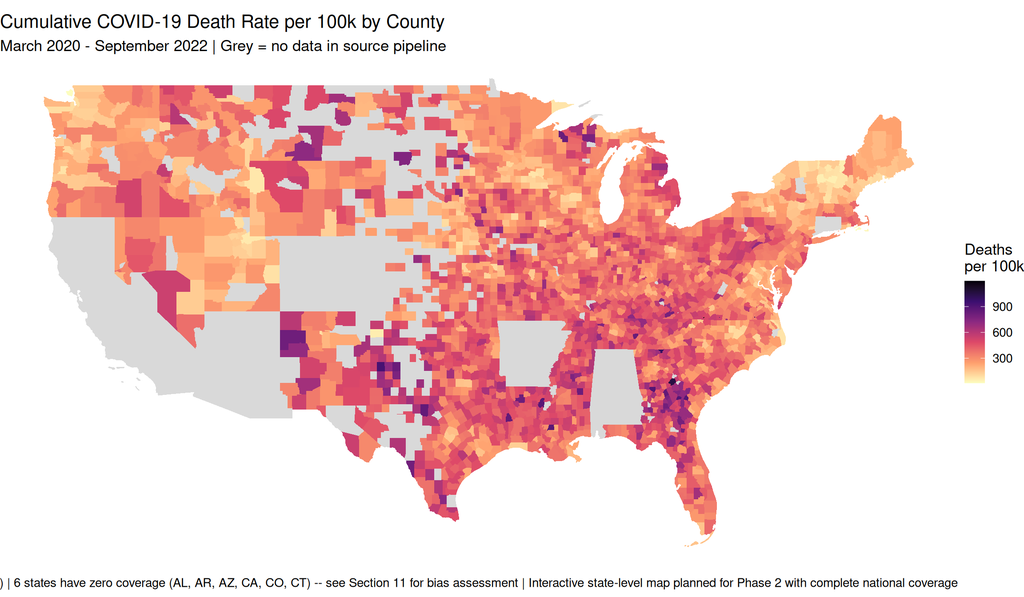

Choropleth: Cumulative COVID Death Rate per 100k by County

```r
invisible(gc())  # trigger garbage collection silently -- suppresses memory table output
# counties_sf pre-loaded in tigris_setup chunk
# No download needed -- using cached version

map_data <- counties_sf %>%
  left_join(county_totals, by = "fips")

ggplot(map_data) +
  geom_sf(aes(fill = cum_death_rate), color = NA) +
  scale_fill_viridis_c(
    option    = "magma",
    direction = -1,
    name      = "Deaths\nper 100k",
    na.value  = "grey85",
    labels    = comma
  ) +
  labs(
    title    = "Cumulative COVID-19 Death Rate per 100k by County",
    subtitle = "March 2020 - September 2022 | Grey = no data in source pipeline",
    caption  = paste0(
      "Source: Google COVID-19 Open Data + ACS 2019 5-Year | ",
    "Coverage: 2,904 of ~3,143 US counties (92%) | ",
    "6 states have zero coverage (AL, AR, AZ, CA, CO, CT) -- ",
    "see Section 11 for bias assessment | ",
    "Interactive state-level map planned for Phase 2 ",
    "with complete national coverage"
    )
  ) +
  theme_void(base_size = 13) +
  theme(legend.position = "right")
```

# 5. Case-Fatality Relationship by County

> **Relationship Between Cumulative Case Rate and Death Rate by County**

```r
library(plotly)

# Build tooltip text for county points
cfr_plot_data <- county_totals %>%
  filter(!is.na(cfr_overall), cfr_overall < 0.3) %>%
  mutate(
    tooltip_text = paste0(
      "<b>", county_name, ", ", state_name, "</b><br>",
      "Death Rate: ",  round(cum_death_rate, 1), " per 100k<br>",
      "Case Rate: ",   round(cum_case_rate,  1), " per 100k<br>",
      "CFR: ",         scales::percent(cfr_overall, accuracy = 0.1), "<br>",
      "Population: ",  scales::comma(total_pop), "<br>",
      "% Age 65+: ",   scales::percent(pct_65_over,  accuracy = 0.1), "<br>",
      "Poverty Rate: ",scales::percent(poverty_rate, accuracy = 0.1), "<br>",
      "% Black: ",     scales::percent(pct_black,    accuracy = 0.1)
    )
  )

# Fit the regression model explicitly to build
# tooltip-bearing reference points along the line
lm_fit    <- lm(cum_death_rate ~ cum_case_rate, data = cfr_plot_data)
lm_r2     <- summary(lm_fit)$r.squared
lm_slope  <- coef(lm_fit)[2]
lm_int    <- coef(lm_fit)[1]
lm_pval   <- summary(lm_fit)$coefficients[2, 4]

# Build 50 reference points along the regression line
# These carry the tooltip and are rendered as invisible points
case_range <- seq(min(cfr_plot_data$cum_case_rate, na.rm = TRUE),
                  max(cfr_plot_data$cum_case_rate, na.rm = TRUE),
                  length.out = 50)

lm_line_data <- tibble(
  cum_case_rate  = case_range,
  cum_death_rate = lm_int + lm_slope * case_range,
  tooltip_text   = paste0(
    "<b>National OLS Regression Line</b><br>",
    "At this case rate: ",
    scales::comma(round(case_range, 0)), " per 100k<br>",
    "Expected death rate: ",
    round(lm_int + lm_slope * case_range, 1), " per 100k<br>",
    "────────────────────<br>",
    "Slope: ", round(lm_slope, 4),
    " deaths per case (per 100k)<br>",
    "Intercept: ", round(lm_int, 1), "<br>",
    "R²: ", round(lm_r2, 3), "<br>",
    "p-value: ", scales::pvalue(lm_pval), "<br>",
    "────────────────────<br>",
    "<i>Points above this line = higher than",
    " expected death rate</i><br>",
    "<i>Points below = lower than expected</i>"
  )
)

# Build confidence interval band data
pred_data  <- predict(lm_fit,
                      newdata   = tibble(cum_case_rate = case_range),
                      interval  = "confidence",
                      level     = 0.95) %>%
  as_tibble() %>%
  mutate(
    cum_case_rate = case_range,
    tooltip_text  = paste0(
      "<b>95% Confidence Band</b><br>",
      "At case rate: ",
      scales::comma(round(case_range, 0)), " per 100k<br>",
      "Expected death rate: ", round(fit,  1), " per 100k<br>",
      "95% CI lower: ",        round(lwr,  1), " per 100k<br>",
      "95% CI upper: ",        round(upr,  1), " per 100k<br>",
      "────────────────────<br>",
      "<i>Band width reflects uncertainty in the",
      " national average at each case rate level</i>"
    )
  )

# Build the plot
p_cfr <- ggplot() +

  # Confidence band as ribbon -- invisible fill, tooltip via points
  geom_ribbon(data = pred_data,
              aes(x = cum_case_rate, ymin = lwr, ymax = upr),
              fill = "grey70", alpha = 0.25, inherit.aes = FALSE) +

  # Invisible points along CI band upper edge for tooltips
  geom_point(data = pred_data,
             aes(x = cum_case_rate, y = upr, text = tooltip_text),
             size = 0, alpha = 0, inherit.aes = FALSE) +

  # Invisible points along CI band lower edge for tooltips
  geom_point(data = pred_data,
             aes(x = cum_case_rate, y = lwr, text = tooltip_text),
             size = 0, alpha = 0, inherit.aes = FALSE) +

  # County scatter points
  geom_point(data = cfr_plot_data,
             aes(x     = cum_case_rate,
                 y     = cum_death_rate,
                 color = pct_65_over,
                 size  = total_pop,
                 text  = tooltip_text),
             alpha = 0.6) +

  # Regression line as visible dashed line
  geom_line(data = lm_line_data,
            aes(x = cum_case_rate, y = cum_death_rate),
            color    = "black",
            linewidth = 0.8,
            linetype = "dashed",
            inherit.aes = FALSE) +

  # Invisible points along regression line carrying tooltip
  geom_point(data = lm_line_data,
             aes(x = cum_case_rate, y = cum_death_rate,
                 text = tooltip_text),
             size = 0, alpha = 0, inherit.aes = FALSE) +

  scale_color_viridis_c(
    name   = "% Age 65+",
    labels = percent,
    option = "viridis"
  ) +
  scale_size_continuous(
    name   = "Population",
    labels = comma,
    range  = c(0.5, 6)
  ) +
  scale_x_continuous(labels = comma) +
  scale_y_continuous(labels = comma) +
  labs(
    title    = "Cumulative Case Rate vs. Death Rate by County",
    subtitle = paste0(
      "Color = % population 65+  |  Size = county population  |  ",
      "Hover points OR regression line for detail"
    ),
    x       = "Cumulative Cases per 100k",
    y       = "Cumulative Deaths per 100k",
    caption = "Dashed line = OLS fit | Grey band = 95% confidence interval"
  ) +
  theme_minimal(base_size = 13)

# Convert to interactive plotly
ggplotly(p_cfr, tooltip = "text") %>%
  layout(
    hoverlabel = list(
      bgcolor     = "white",
      font        = list(size = 12),
      bordercolor = "grey40"
    ),
    legend = list(orientation = "v", x = 1.05)
  )
```

[interactive chart not shown]

Relationship between cumulative case rate and death rate by county

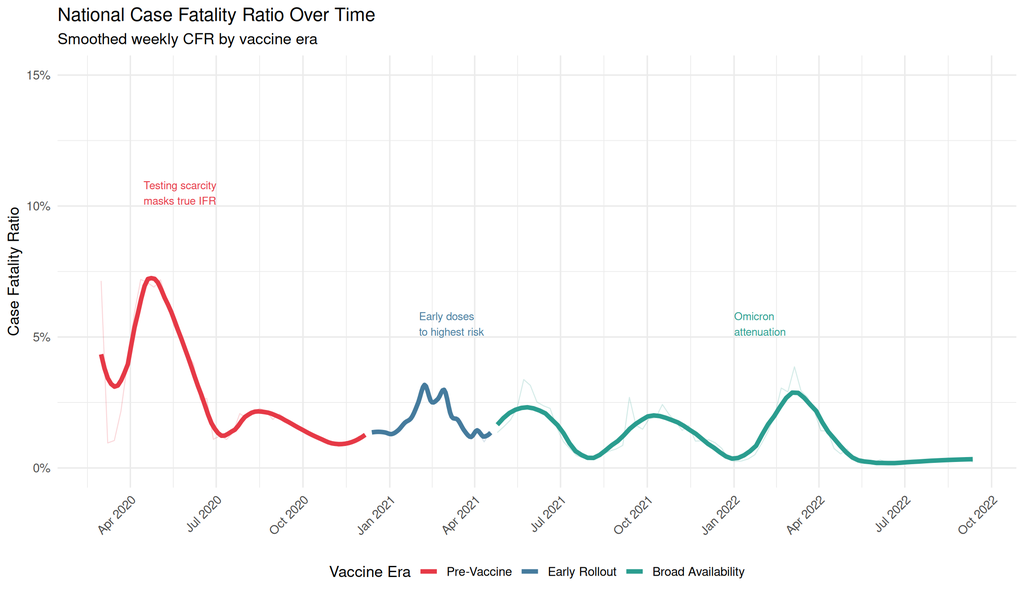

Case fatality ratio over time by vaccine era

```r
county_weekly %>%
  filter(new_deceased_wk >= 0, new_confirmed_wk > 0) %>%
  mutate(
    vaccine_era_label = recode(vaccine_era,
      "pre_vaccine"        = "Pre-Vaccine",
      "early_rollout"      = "Early Rollout",
      "broad_availability" = "Broad Availability"
    )
  ) %>%
  group_by(week_start, vaccine_era_label) %>%
  summarise(
    cfr_wk = sum(new_deceased_wk, na.rm = TRUE) /
              pmax(sum(new_confirmed_wk, na.rm = TRUE), 1),
    .groups = "drop"
  ) %>%
  ggplot(aes(x = week_start, y = cfr_wk,
             color = vaccine_era_label,
             group = vaccine_era_label)) +
  geom_line(alpha = 0.2, linewidth = 0.4) +
  geom_smooth(method    = "loess",
              se        = FALSE,
              linewidth = 1.8,
              span      = 0.3) +
  scale_color_manual(
    values = c(
      "Pre-Vaccine"        = "#E63946",
      "Early Rollout"      = "#457B9D",
      "Broad Availability" = "#2A9D8F"
    ),
    name = "Vaccine Era"
  ) +
  scale_x_date(date_breaks = "3 months", date_labels = "%b %Y") +
  scale_y_continuous(labels = percent, limits = c(0, 0.15)) +
  annotate("text",
           x     = as.Date("2020-04-15"),
           y     = 0.105,
           label = "Testing scarcity\nmasks true IFR",
           size  = 3.2,
           color = "#E63946",
           hjust = 0) +
  annotate("text",
           x     = as.Date("2021-02-01"),
           y     = 0.055,
           label = "Early doses\nto highest risk",
           size  = 3.2,
           color = "#457B9D",
           hjust = 0) +
  annotate("text",
           x     = as.Date("2022-01-01"),
           y     = 0.055,
           label = "Omicron\nattenuation",
           size  = 3.2,
           color = "#2A9D8F",
           hjust = 0) +
  labs(
    title    = "National Case Fatality Ratio Over Time",
    subtitle = "Smoothed weekly CFR by vaccine era",
    x        = NULL,
    y        = "Case Fatality Ratio"
  ) +
  theme_minimal(base_size = 13) +
  theme(
    axis.text.x     = element_text(angle = 45, hjust = 1),
    legend.position = "bottom"
  )
```

# 6. Demographic Drivers of Death Rate

Before building the formal regression model in Section 7, this section examines how individual demographic characteristics relate to county COVID death rates. This serves as an analytical screening step — identifying which variables deserve inclusion in the model and previewing the direction of each relationship.

### Reading the Correlation Table

Pearson correlation measures the linear relationship between two variables on a scale from -1.0 to 1.0. A value close to 1.0 means the two variables tend to rise and fall together — as one increases the other increases. A value close to -1.0 means they move in opposite directions — as one increases the other decreases. A value near zero means little to no linear relationship exists between them.

The table below ranks each demographic variable by the strength of its relationship with cumulative COVID death rate. Variables near the top of the list are the strongest candidates for the regression model. Variables near the bottom have weaker relationships and may lose statistical significance after other factors are controlled for.

> **Important Limitation:** Correlation measures association, not causation. A strong correlation between two variables does not mean one caused the other. Many of these demographic characteristics are themselves correlated with each other — counties with high poverty rates also tend to have lower educational attainment, for example. The regression model in Section 7 formally separates these overlapping relationships to identify which factors have independent predictive power after controlling for the others.

```r
demo_vars <- county_totals %>%
  dplyr::select(cum_death_rate, pct_65_over, pct_black, pct_hispanic,
         pct_white, poverty_rate, pct_no_cars, median_age,
         pop_per_housing_unit, pct_less_than_hs) %>%
  drop_na()

cor(demo_vars, use = "complete.obs") %>%
  as.data.frame() %>%
  rownames_to_column("variable") %>%
  select(variable, cum_death_rate) %>%
  filter(variable != "cum_death_rate") %>%
  arrange(desc(abs(cum_death_rate))) %>%
  mutate(cum_death_rate = round(cum_death_rate, 3)) %>%
  rename(correlation_with_death_rate = cum_death_rate) %>%
  mutate(variable = recode(variable,
    "pct_less_than_hs"     = "% Without HS Diploma",
    "poverty_rate"         = "Poverty Rate",
    "pct_65_over"          = "% Age 65+",
    "pct_black"            = "% Black Population",
    "pct_no_cars"          = "% No Car Access",
    "pct_white"            = "% White Population",
    "median_age"           = "Median Age",
    "pop_per_housing_unit" = "Pop. per Housing Unit",
    "pct_hispanic"         = "% Hispanic Population"
  )) %>%
  kable(caption = "Pearson Correlation: Demographic Variables vs. Cumulative Death Rate") %>%
  kable_styling(bootstrap_options = c("striped", "hover"))
```

Pearson Correlation: Demographic Variables vs. Cumulative Death Rate

| variable | correlation_with_death_rate |
| --- | --- |
| % Without HS Diploma | 0.517 |
| Poverty Rate | 0.444 |
| % Age 65+ | 0.193 |
| % Black Population | 0.179 |
| % No Car Access | 0.152 |
| % White Population | -0.138 |
| Median Age | 0.126 |
| Pop. per Housing Unit | -0.112 |
| % Hispanic Population | 0.059 |

### COVID Death Rates by Black Population Share

The correlation table identifies Black population share as the fourth strongest predictor of county COVID death rates. Combined with the finding that persistently high burden counties have nearly three times the national average Black population share (22.9% vs 8.4%), a closer examination of how death rates vary across counties grouped by Black population concentration is warranted.

The chart below divides all counties into four equal groups — quartiles — ranked from lowest to highest Black population share. If Black population share has a meaningful relationship with COVID mortality the groups with higher Black population shares should show systematically higher death rates.

> **Analytical Note:** This analysis examines population-level patterns at the county level — not individual-level outcomes. A county with a high Black population share experiencing elevated death rates does not mean Black residents specifically drove that outcome. It means something about the structural characteristics of counties with those demographic profiles — healthcare access, poverty, educational attainment — predicted worse outcomes. The regression model in Section 7 formally tests which structural factors explain this pattern.

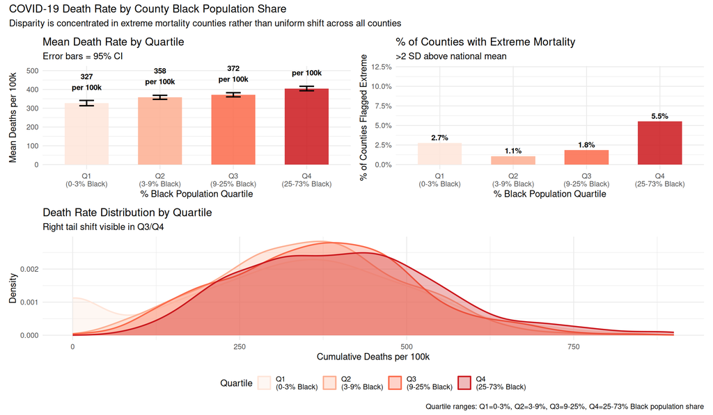

Death rate patterns by Black population quartile

```r
library(patchwork)

# Prepare quartile data
race_data <- county_totals %>%
  mutate(
    pct_black_q = ntile(pct_black, 4),
    pct_black_q = factor(pct_black_q,
                         labels = c("Q1\n(0-3% Black)",
                                    "Q2\n(3-9% Black)",
                                    "Q3\n(9-25% Black)",
                                    "Q4\n(25-73% Black)"))
  ) %>%
  filter(!is.na(pct_black_q))

# Panel 1: Mean death rate with error bars -- clearest view of shift
p1 <- race_data %>%
  group_by(pct_black_q) %>%
  summarise(
    mean_dr = mean(cum_death_rate,  na.rm = TRUE),
    se_dr   = sd(cum_death_rate,    na.rm = TRUE) /
              sqrt(n()),
    n       = n(),
    .groups = "drop"
  ) %>%
  ggplot(aes(x = pct_black_q, y = mean_dr, fill = pct_black_q)) +
  geom_col(width = 0.6, alpha = 0.85) +
  geom_errorbar(aes(ymin = mean_dr - 1.96 * se_dr,
                    ymax = mean_dr + 1.96 * se_dr),
                width = 0.2, linewidth = 0.8) +
  geom_text(aes(label = paste0(round(mean_dr, 0), "\nper 100k")),
            vjust = -0.8, size = 3.2, fontface = "bold") +
  scale_fill_brewer(palette = "Reds") +
  scale_y_continuous(labels = comma,
                     limits = c(0, 500)) +
  labs(
    title    = "Mean Death Rate by Quartile",
    subtitle = "Error bars = 95% CI",
    x        = "% Black Population Quartile",
    y        = "Mean Deaths per 100k"
  ) +
  theme_minimal(base_size = 11) +
  theme(legend.position = "none")

# Panel 2: Proportion of extreme mortality counties per quartile
p2 <- race_data %>%
  mutate(extreme = cum_death_rate >
           (mean(cum_death_rate, na.rm = TRUE) +
            2 * sd(cum_death_rate, na.rm = TRUE))) %>%
  group_by(pct_black_q) %>%
  summarise(
    pct_extreme = mean(extreme, na.rm = TRUE),
    n           = n(),
    .groups     = "drop"
  ) %>%
  ggplot(aes(x = pct_black_q, y = pct_extreme, fill = pct_black_q)) +
  geom_col(width = 0.6, alpha = 0.85) +
  geom_text(aes(label = scales::percent(pct_extreme, accuracy = 0.1)),
            vjust = -0.5, size = 3.2, fontface = "bold") +
  scale_fill_brewer(palette = "Reds") +
  scale_y_continuous(labels = percent,
                     limits = c(0, 0.12)) +
  labs(
    title    = "% of Counties with Extreme Mortality",
    subtitle = ">2 SD above national mean",
    x        = "% Black Population Quartile",
    y        = "% of Counties Flagged Extreme"
  ) +
  theme_minimal(base_size = 11) +
  theme(legend.position = "none")

# Panel 3: Cumulative death rate density by quartile
p3 <- race_data %>%
  ggplot(aes(x = cum_death_rate,
             fill = pct_black_q,
             color = pct_black_q)) +
  geom_density(alpha = 0.3, linewidth = 0.8) +
  scale_fill_brewer(palette  = "Reds", name = "Quartile") +
  scale_color_brewer(palette = "Reds", name = "Quartile") +
  scale_x_continuous(labels = comma, limits = c(0, 900)) +
  labs(
    title    = "Death Rate Distribution by Quartile",
    subtitle = "Right tail shift visible in Q3/Q4",
    x        = "Cumulative Deaths per 100k",
    y        = "Density"
  ) +
  theme_minimal(base_size = 11) +
  theme(legend.position = "bottom")

# Compose with patchwork
(p1 | p2) / p3 +
  plot_annotation(
    title   = "COVID-19 Death Rate by County Black Population Share",
    subtitle = paste0(
      "Disparity is concentrated in extreme mortality counties ",
      "rather than uniform shift across all counties"
    ),
    caption = "Quartile ranges: Q1=0-3%, Q2=3-9%, Q3=9-25%, Q4=25-73% Black population share"
  )
```

# 7. Excess Mortality Regression Model

To formally test whether structural factors predicted county COVID death rates after controlling for age, a Negative Binomial regression model was fitted to cumulative county death counts. This model was chosen over simpler alternatives because COVID death counts are overdispersed — the variation between counties is far greater than a standard Poisson model assumes. The Negative Binomial model handles this property correctly and produces honest confidence intervals as a result.

Counties with zero recorded deaths and populations below 5,000 were excluded from the model. Very small counties produce statistically unstable rates — a single death in a community of 800 people generates a death rate that looks catastrophic per 100,000 but represents one family’s loss rather than a systematic pattern.

> **How to Read the Results:** The model produces Incidence Rate Ratios (IRR) for each variable. An IRR greater than 1.0 means that factor is associated with a higher death rate. An IRR less than 1.0 means it is associated with a lower death rate. An IRR of exactly 1.0 means no relationship. The further a value sits from 1.0 in either direction, the stronger the relationship.

> For example, an IRR of 3.7 for poverty rate means counties with the highest poverty rates had approximately 3.7 times the expected death rate of counties with the lowest poverty rates, after accounting for every other variable in the model simultaneously.

> **Statistical significance** is indicated in the Significant column. Variables marked Yes have relationships strong enough that we can be confident they are real rather than the result of random chance. Variables marked No — specifically Black population share and car access — did not retain independent statistical significance after structural factors were controlled for. This is itself an important finding, explained below.

```r
model_data <- county_totals %>%
  dplyr::select(total_deceased, total_pop, pct_65_over, pct_black,
         pct_hispanic, poverty_rate, pct_no_cars, median_age,
         pop_per_housing_unit, pct_less_than_hs) %>%
  drop_na() %>%
  filter(total_deceased > 0, total_pop > 5000)

nb_model <- glm.nb(
  total_deceased ~
    offset(log(total_pop)) +
    pct_65_over +
    pct_black +
    pct_hispanic +
    poverty_rate +
    pct_no_cars +
    median_age +
    pop_per_housing_unit +
    pct_less_than_hs,
  data = model_data
)

summary(nb_model)
```

```
##
## Call:
## glm.nb(formula = total_deceased ~ offset(log(total_pop)) + pct_65_over +
##     pct_black + pct_hispanic + poverty_rate + pct_no_cars + median_age +
##     pop_per_housing_unit + pct_less_than_hs, data = model_data,
##     init.theta = 9.941928556, link = log)
##
## Coefficients:
##                       Estimate Std. Error z value Pr(>|z|)
## (Intercept)          -6.888070   0.154940 -44.456  < 2e-16 ***
## pct_65_over           4.853089   0.438326  11.072  < 2e-16 ***
## pct_black            -0.043251   0.054236  -0.797 0.425185
## pct_hispanic         -0.309345   0.063283  -4.888 1.02e-06 ***
## poverty_rate          1.319615   0.185944   7.097 1.28e-12 ***
## pct_no_cars          -0.179513   0.494744  -0.363 0.716724
## median_age           -0.014624   0.003784  -3.865 0.000111 ***
## pop_per_housing_unit  0.197183   0.031925   6.176 6.56e-10 ***
## pct_less_than_hs      4.448984   0.252191  17.641  < 2e-16 ***
## ---
## Signif. codes:  0 '***' 0.001 '**' 0.01 '*' 0.05 '.' 0.1 ' ' 1
##
## (Dispersion parameter for Negative Binomial(9.9419) family taken to be 1)
##
##     Null deviance: 3941.8  on 2539  degrees of freedom
## Residual deviance: 2645.8  on 2531  degrees of freedom
## AIC: 26490
##
## Number of Fisher Scoring iterations: 1
##
##
##               Theta:  9.942
##           Std. Err.:  0.312
##
##  2 x log-likelihood:  -26469.658
```

```r
tidy(nb_model, conf.int = TRUE, exponentiate = TRUE) %>%
  filter(term != "(Intercept)") %>%
  mutate(across(c(estimate, conf.low, conf.high), ~round(., 3)),
         p.value     = scales::pvalue(p.value),
         significant = if_else(p.value < 0.05, "Yes", "No")) %>%
  rename(IRR = estimate, CI_low = conf.low, CI_high = conf.high) %>%
  kable(caption = "Negative Binomial Model: Incidence Rate Ratios") %>%
  kable_styling(bootstrap_options = c("striped", "hover"))
```

Negative Binomial Model: Incidence Rate Ratios

| term | IRR | std.error | statistic | p.value | CI_low | CI_high | significant |
| --- | --- | --- | --- | --- | --- | --- | --- |
| pct_65_over | 128.136 | 0.4383264 | 11.0718604 | <0.001 | 50.828 | 324.282 | Yes |
| pct_black | 0.958 | 0.0542364 | -0.7974590 | 0.425 | 0.859 | 1.068 | No |
| pct_hispanic | 0.734 | 0.0632832 | -4.8882652 | <0.001 | 0.648 | 0.832 | Yes |
| poverty_rate | 3.742 | 0.1859442 | 7.0968360 | <0.001 | 2.579 | 5.433 | Yes |
| pct_no_cars | 0.836 | 0.4947440 | -0.3628412 | 0.717 | 0.323 | 2.256 | No |
| median_age | 0.985 | 0.0037837 | -3.8649235 | <0.001 | 0.978 | 0.993 | Yes |
| pop_per_housing_unit | 1.218 | 0.0319255 | 6.1763563 | <0.001 | 1.140 | 1.301 | Yes |
| pct_less_than_hs | 85.540 | 0.2521906 | 17.6413601 | <0.001 | 51.239 | 142.991 | Yes |

### What the Model Found

The results challenge the dominant narrative of the pandemic response in important ways.

**Education was the strongest predictor.** Counties where more adults lack a high school diploma had dramatically higher COVID death rates — an IRR of 85.5 — after accounting for age, race, poverty, and every other variable simultaneously. This is not primarily a story about individual health decisions. Educational attainment at the county level reflects decades of investment in schools, economic opportunity, healthcare access, and community infrastructure. Counties with lower educational attainment had less of everything that protects a community during a health emergency.

**Poverty independently predicted death rates.** An IRR of 3.7 for poverty rate means high-poverty counties had nearly four times the expected death rate of low-poverty counties after controlling for everything else. Poverty and education are related but the model confirms they represent distinct dimensions of structural vulnerability — both matter independently.

**Hispanic population share was protective.** After controlling for poverty and education, counties with higher Hispanic population shares had lower expected death rates — an IRR of 0.73. This is consistent with what epidemiologists call the Hispanic Health Paradox — Hispanic communities in the United States consistently show better health outcomes than their socioeconomic characteristics alone would predict.

**Black population share was not a statistically significant independent predictor.** This is the finding that most directly speaks to structural inequity. After controlling for educational attainment and poverty — the structural conditions that disproportionately characterize majority Black counties due to historical policy choices — Black population share itself had no statistically significant independent effect on death rates (IRR 0.958, p=0.425). The disparity documented throughout this analysis is real and severe. But it is not explained by race as an inherent risk factor. It is explained by the structural conditions that were imposed on these communities over generations and that COVID exposed with devastating clarity.

> **What This Means for Policy:** You cannot address the mortality disparity documented in this analysis by targeting race as a category. The data says the intervention points are educational investment, poverty reduction, and healthcare infrastructure in structurally disadvantaged communities — which disproportionately but not exclusively serve majority Black populations in the Deep South. Targeting the structural conditions rather than the demographic category is both more analytically defensible and more likely to produce lasting change.

```r
library(plotly)

irr_data <- tidy(nb_model, conf.int = TRUE, exponentiate = TRUE) %>%
  filter(term != "(Intercept)") %>%
  mutate(
    term_clean = recode(term,
      pct_65_over          = "% Age 65+",
      pct_black            = "% Black Population",
      pct_hispanic         = "% Hispanic Population",
      poverty_rate         = "Poverty Rate",
      pct_no_cars          = "% No Car Access",
      median_age           = "Median Age",
      pop_per_housing_unit = "Pop. per Housing Unit",
      pct_less_than_hs     = "% Without HS Diploma"
    ),
    direction = if_else(estimate > 1, "Risk Factor", "Protective"),

    # Plain language interpretation for tooltip
    plain_language = case_when(
      term == "pct_less_than_hs" ~ paste0(
        "Counties with the highest share of adults\n",
        "without a high school diploma have\n",
        round(estimate, 1), "x the expected death rate\n",
        "of counties with the lowest share,\n",
        "after controlling for all other factors."
      ),
      term == "pct_65_over" ~ paste0(
        "Counties with the highest elderly population\n",
        "share have ", round(estimate, 1), "x the expected\n",
        "death rate of counties with the lowest share,\n",
        "after controlling for all other factors."
      ),
      term == "poverty_rate" ~ paste0(
        "Counties with the highest poverty rates\n",
        "have ", round(estimate, 2), "x the expected death rate\n",
        "of counties with the lowest poverty rates,\n",
        "after controlling for all other factors."
      ),
      term == "pop_per_housing_unit" ~ paste0(
        "Each additional person per housing unit\n",
        "multiplies the expected death rate by ",
        round(estimate, 3), ".\n",
        "Crowding independently amplifies transmission risk."
      ),
      term == "median_age" ~ paste0(
        "After controlling for % age 65+,\n",
        "higher median age is associated with\n",
        round((1 - estimate) * 100, 1), "% LOWER expected death rate.\n",
        "Likely reflects affluent retirement communities\n",
        "with better healthcare access."
      ),
      term == "pct_black" ~ paste0(
        "After controlling for education and poverty,\n",
        "Black population share has NO statistically\n",
        "significant independent effect (p=0.425).\n",
        "The disparity observed in Black communities\n",
        "is explained by structural conditions --\n",
        "not race as an independent risk factor."
      ),
      term == "pct_no_cars" ~ paste0(
        "No Car Access is NOT statistically significant\n",
        "after controlling for poverty and education.\n",
        "The wide confidence interval (0.32 to 2.26)\n",
        "reflects high uncertainty in this estimate."
      ),
      term == "pct_hispanic" ~ paste0(
        "After controlling for poverty and education,\n",
        "higher Hispanic population share is associated\n",
        "with ", round((1 - estimate) * 100, 1), "% LOWER expected death rate.\n",
        "Consistent with the Hispanic Health Paradox --\n",
        "better outcomes than socioeconomic factors predict."
      )
    ),

    # Full tooltip text
    tooltip_text = paste0(
      "<b>", term_clean, "</b><br>",
      "────────────────────────<br>",
      "<b>IRR: ", round(estimate, 3), "</b>",
      "  (", round(conf.low, 3), " to ", round(conf.high, 3), ")<br>",
      "p-value: ", scales::pvalue(p.value), "<br>",
      "Significant: ", if_else(p.value < 0.05, "Yes ✓", "No ✗"), "<br>",
      "────────────────────────<br>",
      "<i>", plain_language, "</i>"
    )
  )

# Build forest plot
p_forest <- ggplot(irr_data,
                   aes(x    = estimate,
                       y    = reorder(term_clean, estimate),
                       color = direction,
                       text  = tooltip_text)) +
  geom_vline(xintercept = 1,
             linetype   = "dashed",
             color      = "grey50") +
  geom_errorbarh(aes(xmin = conf.low, xmax = conf.high),
                 height    = 0.2,
                 color     = "grey40") +
  geom_point(size = 4) +
  scale_color_manual(
    values = c("Risk Factor" = "#E63946",
               "Protective"  = "#457B9D"),
    name   = NULL
  ) +
  scale_x_log10(
    breaks = c(0.5, 0.75, 1, 1.5, 2, 5, 10, 50, 100, 200),
    labels = c("0.5", "0.75", "1", "1.5", "2", "5",
               "10", "50", "100", "200")
  ) +
  labs(
    title    = "Incidence Rate Ratios: County COVID-19 Death Rate",
    subtitle = "Negative Binomial Model | Log scale | Hover each point for plain language interpretation",
    x        = "Incidence Rate Ratio (IRR) — Log Scale",
    y        = NULL
  ) +
  theme_minimal(base_size = 13) +
  theme(legend.position = "bottom")

# Convert to interactive plotly
ggplotly(p_forest, tooltip = "text") %>%
  layout(
    hoverlabel = list(
      bgcolor     = "white",
      font        = list(size = 12),
      bordercolor = "grey40",
      align       = "left"
    ),
    legend = list(orientation = "h", y = -0.15)
  )
```

[interactive chart not shown]

Forest plot of Incidence Rate Ratios

# 8. Seasonal Decomposition

Respiratory diseases have long followed seasonal patterns — winter brings people indoors, reduces ventilation, lowers vitamin D levels, and creates conditions that favor airborne transmission. Influenza, RSV, and the common cold all peak in the November through February window in the Northern Hemisphere. The question for COVID-19 is whether it followed the same pattern — and if so, what that tells us about the communities that were already structurally vulnerable when winter arrived.

To answer this, STL decomposition was applied to the national weekly death rate time series. STL — Seasonal-Trend decomposition using Loess — mathematically separates a time series into three distinct components:

- **Trend** — the underlying long-term direction of mortality, smoothed across a 13-week window (one meteorological season) to remove short-term noise
- **Seasonal** — the repeating annual cycle of higher winter and lower summer mortality, extracted as the pattern that recurs at the same time each year
- **Remainder** — what is left after trend and season are removed; genuine anomalies that neither the long-term direction nor the calendar can explain

STL was chosen over classical decomposition methods because it is robust to outliers — a pandemic with multiple extreme waves requires a decomposition method that can identify seasonal patterns without being distorted by the waves themselves.

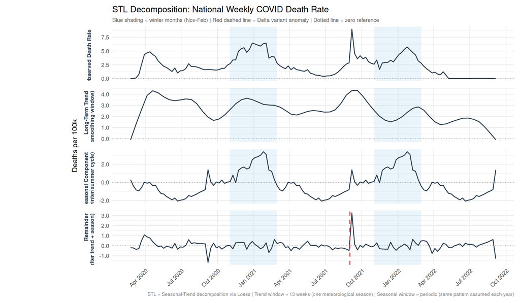

STL decomposition of national weekly death rate

```r
# ============================================================
# SEASONAL PREP + STL DECOMPOSITION -- combined into one chunk
# to ensure stl_fit is available in the knit environment
# ============================================================

national_ts <- county_weekly %>%
  group_by(week_start) %>%
  summarise(
    death_rate_nat = weighted.mean(death_rate_wk,
                                   total_pop, na.rm = TRUE),
    .groups = "drop"
  ) %>%
  arrange(week_start) %>%
  filter(!is.na(death_rate_nat))

national_tsibble <- national_ts %>%
  mutate(week = yearweek(week_start)) %>%
  as_tsibble(index = week)

stl_fit <- national_tsibble %>%
  model(STL(death_rate_nat ~ trend(window = 13) +
              season(window = "periodic")))

# Extract components
stl_components <- components(stl_fit)

stl_df <- stl_components %>%
  as_tibble() %>%
  mutate(date = as.Date(week))

stl_long <- stl_df %>%
  dplyr::select(date, death_rate_nat, trend,
                season_year, remainder) %>%
  pivot_longer(
    cols      = c(death_rate_nat, trend,
                  season_year, remainder),
    names_to  = "component",
    values_to = "value"
  ) %>%
  mutate(
    component = factor(component,
      levels = c("death_rate_nat", "trend",
                 "season_year",    "remainder"),
      labels = c(
        "Observed Death Rate",
        "Long-Term Trend\n(13-week smoothing window)",
        "Seasonal Component\n(repeating winter/summer cycle)",
        "Remainder\n(unexplained after trend + season)"
      )
    )
  )

winter_bands <- tibble(
  xmin  = as.Date(c("2020-11-01", "2021-11-01")),
  xmax  = as.Date(c("2021-02-28", "2022-02-28")),
  label = c("Winter\n2020-21", "Winter\n2021-22")
)

ggplot(stl_long, aes(x = date, y = value)) +
  geom_rect(
    data        = winter_bands,
    aes(xmin = xmin, xmax = xmax,
        ymin = -Inf, ymax = Inf),
    inherit.aes = FALSE,
    fill        = "#AED6F1",
    alpha       = 0.25
  ) +
  geom_hline(yintercept = 0,
             linetype   = "dotted",
             color      = "grey60",
             linewidth  = 0.5) +
  geom_line(color = "#2C3E50", linewidth = 0.7) +
  geom_vline(
    data = data.frame(
      component = factor(
        "Remainder\n(unexplained after trend + season)",
        levels    = levels(stl_long$component)
      ),
      date = as.Date("2021-09-01")
    ),
    aes(xintercept = date),
    color       = "#E63946",
    linetype    = "dashed",
    linewidth   = 0.8,
    inherit.aes = FALSE
  ) +
  facet_wrap(~component,
             ncol           = 1,
             scales         = "free_y",
             strip.position = "left") +
  scale_x_date(
    date_breaks  = "3 months",
    date_labels  = "%b %Y",
    minor_breaks = NULL
  ) +
  scale_y_continuous(
    labels = number_format(accuracy = 0.1)
  ) +
  labs(
    title    = "STL Decomposition: National Weekly COVID Death Rate",
    subtitle = paste0(
      "Blue shading = winter months (Nov-Feb) | ",
      "Red dashed line = Delta variant anomaly | ",
      "Dotted line = zero reference"
    ),
    x       = NULL,
    y       = "Deaths per 100k",
    caption = paste0(
      "STL = Seasonal-Trend decomposition via Loess | ",
      "Trend window = 13 weeks (one meteorological season) | ",
      "Seasonal window = periodic (same pattern assumed each year)"
    )
  ) +
  theme_minimal(base_size = 12) +
  theme(
    strip.placement  = "outside",
    strip.text.y     = element_text(
      angle    = 0,
      hjust    = 1,
      size     = 9,
      face     = "bold",
      color    = "#2C3E50"
    ),
    axis.text.x      = element_text(angle = 45, hjust = 1),
    panel.spacing    = unit(0.8, "lines"),
    plot.subtitle    = element_text(size = 9, color = "grey40"),
    plot.caption     = element_text(size = 8, color = "grey50"),
    plot.margin      = margin(t = 10, r = 10,
                              b = 10, l = 120, unit = "pt")
  )
```

### Reading the Decomposition

The four panels work together to tell a complete story about what drove national COVID mortality at any given moment.

**Panel 1 — Observed Death Rate** is simply the raw weekly data — the actual measured mortality rate before any mathematical separation. The pandemic waves are all visible here: the initial spring 2020 outbreak, the summer 2020 Sunbelt surge, the catastrophic winter 2020-2021 peak, the Delta spike, and the Omicron surge followed by decline.

**Panel 4 — Remainder** is largely random noise oscillating around zero — which is what a well-specified decomposition should produce. The one meaningful exception is the sharp positive spike marked with a red dashed line around September 2021. That is the Delta wave’s sudden emergence — more abrupt and more severe than the seasonal pattern predicted, producing a residual that neither trend nor calendar can explain. Delta was a genuinely anomalous event, not simply an amplified seasonal peak.

> **The Seasonal Leading Indicator:** The seasonal component begins rising in October — several weeks before the meteorological definition of winter in November. This leading pattern is epidemiologically accurate. People move indoors in early fall as temperatures drop, creating transmission conditions before the calendar catches up. For the communities bearing the highest structural burden this means the dangerous period begins earlier than winter messaging typically acknowledges.

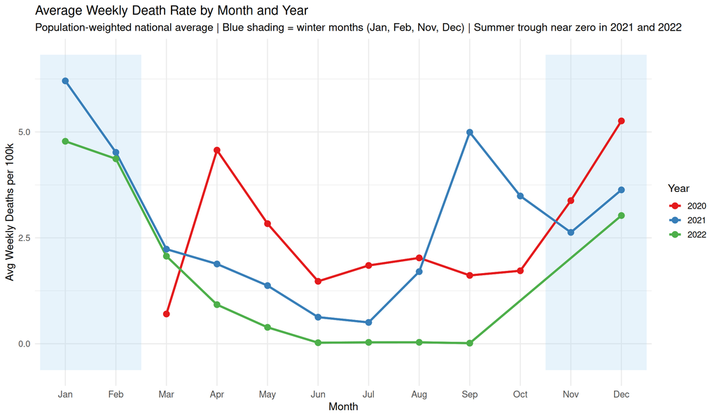

Monthly death rate by year

```r
seasonal_summary <- county_weekly %>%
  mutate(
    month_label = month(week_start, label = TRUE, abbr = TRUE),
    year_fct    = factor(year)
  ) %>%
  group_by(month_label, year_fct) %>%
  summarise(
    death_rate_avg = weighted.mean(death_rate_wk,
                                   total_pop, na.rm = TRUE),
    .groups = "drop"
  ) %>%
  filter(!is.na(month_label))

max_rate <- max(seasonal_summary$death_rate_avg, na.rm = TRUE)

ggplot(seasonal_summary,
       aes(x     = month_label,
           y     = death_rate_avg,
           color = year_fct,
           group = year_fct)) +

  # Lines and points first
  geom_line(linewidth = 1.2) +
  geom_point(size = 3) +

  # Winter shading using geom_tile as background
  # One tile per winter month, full height
  geom_tile(
    data = seasonal_summary %>%
      filter(month_label %in% c("Jan", "Feb", "Nov", "Dec")) %>%
      dplyr::select(month_label) %>%
      distinct() %>%
      mutate(y_mid = max_rate / 2,
             height = max_rate * 1.2),
    aes(x      = month_label,
        y      = y_mid,
        height = height),
    fill        = "#AED6F1",
    alpha       = 0.3,
    inherit.aes = FALSE,
    width       = 1.0
  ) +

  # Redraw lines and points on top of shading
  geom_line(linewidth = 1.2) +
  geom_point(size = 3) +

  scale_color_brewer(palette = "Set1", name = "Year") +

  labs(
    title    = "Average Weekly Death Rate by Month and Year",
    subtitle = paste0(
      "Population-weighted national average | ",
      "Blue shading = winter months (Jan, Feb, Nov, Dec) | ",
      "Summer trough near zero in 2021 and 2022"
    ),
    x       = "Month",
    y       = "Avg Weekly Deaths per 100k"
  ) +
  theme_minimal(base_size = 13) +
  theme(
    axis.text.x = element_text(size = 11)
  )
```

### Seasonal Patterns Across Three Years

The month-by-year chart confirms that the seasonal pattern identified in the decomposition is not a mathematical artifact — it is visible in the raw monthly averages across all three years of the analysis period.

**2021 shows the clearest seasonal shape** — starting high in January as the winter 2020-2021 surge peaked, dropping steadily through spring and summer to near zero in June and July, then rising sharply in September as Delta emerged simultaneously with autumn. The summer floor and autumn rise are exactly what the seasonal component predicted.

**2022 shows the post-Omicron floor** — the lowest death rates of any year across almost every month, consistent with Hypothesis 2’s finding of structural decline in case lethality. But the seasonal shape persists — near zero in summer, rising in fall — confirming that seasonality continued even as the overall mortality level declined dramatically.

**2020 is the anomalous year** — the pandemic arrived in the wrong season. The April peak reflects the initial uncontrolled outbreak hitting a population with zero immunity and zero treatment protocols before lockdowns suppressed transmission through late spring. The 2020 line maps almost precisely onto the policy decisions of that year — lockdowns, reopenings, and the arrival of winter without adequate preparation — rather than the biological seasonal pattern that 2021 and 2022 would establish.

> **Seasonal Equity Note:** The consistent summer trough — near zero in both 2021 and 2022 regardless of variant or vaccination status — suggests that summer provided genuine biological relief to all communities. The communities documented in this analysis as persistently high burden did not escape that summer relief. But they entered each autumn with higher cumulative burden, less healthcare infrastructure, and fewer resources to weather the winter amplification that consistently followed. Seasonality was equal. Its consequences were not.

# 9. Outlier County Detection

```r
library(plotly)

# ============================================================
# Recalculate funnel limits and county flags
# ============================================================
overall_rate <- sum(county_totals$total_deceased, na.rm = TRUE) /
                sum(county_totals$total_pop,      na.rm = TRUE)

pop_range <- seq(
  min(county_totals$total_pop, na.rm = TRUE),
  max(county_totals$total_pop, na.rm = TRUE),
  length.out = 500
)

funnel_limits <- tibble(
  total_pop = pop_range,
  se        = sqrt(overall_rate * (1 - overall_rate) / pop_range),
  ucl_95    = (overall_rate + 1.96 * se) * 100000,
  lcl_95    = (overall_rate - 1.96 * se) * 100000,
  ucl_998   = (overall_rate + 3.09 * se) * 100000,
  lcl_998   = (overall_rate - 3.09 * se) * 100000
)

county_totals <- county_totals %>%
  mutate(
    se_county    = sqrt(overall_rate * (1 - overall_rate) / total_pop),
    ucl_998      = (overall_rate + 3.09 * se_county) * 100000,
    lcl_998      = (overall_rate - 3.09 * se_county) * 100000,
    funnel_flag  = case_when(
      cum_death_rate > ucl_998 ~ "Above 99.8% limit",
      cum_death_rate < lcl_998 ~ "Below 99.8% limit",
      TRUE                     ~ "Within limits"
    ),
    expected_rate = overall_rate * 100000,
    excess_deaths = round(
      (cum_death_rate - overall_rate * 100000) / 100000 * total_pop, 0
    ),

    # Full tooltip for every county
    tooltip_text = paste0(
      "<b>", county_name, ", ", state_name, "</b><br>",
      "────────────────────────<br>",
      "<b>Funnel Status: ", funnel_flag, "</b><br>",
      "────────────────────────<br>",
      "Cumulative Death Rate: ",
      round(cum_death_rate, 1), " per 100k<br>",
      "National Expected Rate: ",
      round(overall_rate * 100000, 1), " per 100k<br>",
      "Difference from Expected: ",
      round(cum_death_rate - overall_rate * 100000, 1),
      " per 100k<br>",
      "Estimated Excess Deaths: ",
      scales::comma(abs(excess_deaths)),
      if_else(excess_deaths >= 0,
              " above expected<br>",
              " below expected<br>"),
      "────────────────────────<br>",
      "Population: ", scales::comma(total_pop), "<br>",
      "% Age 65+: ",
      scales::percent(pct_65_over,  accuracy = 0.1), "<br>",
      "% Black: ",
      scales::percent(pct_black,    accuracy = 0.1), "<br>",
      "Poverty Rate: ",
      scales::percent(poverty_rate, accuracy = 0.1), "<br>",
      "% Without HS Diploma: ",
      scales::percent(pct_less_than_hs, accuracy = 0.1), "<br>",
      "────────────────────────<br>",
      "<i>Upper 99.8% limit at this population: ",
      round(ucl_998, 1), " per 100k</i>"
    )
  )

# ============================================================
# Build base ggplot
# ============================================================
p_funnel <- ggplot() +

  # Control limit ribbons
  geom_ribbon(data = funnel_limits,
              aes(x = total_pop,
                  ymin = lcl_998, ymax = ucl_998),
              fill = "#457B9D", alpha = 0.12,
              inherit.aes = FALSE) +
  geom_ribbon(data = funnel_limits,
              aes(x = total_pop,
                  ymin = lcl_95, ymax = ucl_95),
              fill = "#457B9D", alpha = 0.20,
              inherit.aes = FALSE) +

  # National mean reference line
  geom_hline(
    yintercept = overall_rate * 100000,
    linetype   = "dashed",
    color      = "grey40",
    linewidth  = 0.7
  ) +

  # County points with tooltip
  geom_point(
    data = county_totals,
    aes(x    = total_pop,
        y    = cum_death_rate,
        color = funnel_flag,
        text  = tooltip_text),
    alpha = 0.6,
    size  = 1.8
  ) +

  scale_color_manual(
    values = c(
      "Above 99.8% limit" = "#E63946",
      "Below 99.8% limit" = "#2A9D8F",
      "Within limits"     = "grey60"
    ),
    name = NULL
  ) +
  scale_x_log10(labels = comma) +
  scale_y_continuous(labels = comma) +

  labs(
    title    = "Funnel Plot: County COVID-19 Death Rate vs. Population",
    subtitle = paste0(
      "Hover any county for demographic profile | ",
      "Red = statistically anomalous high burden | ",
      "Teal = anomalous low burden"
    ),
    x       = "County Population (log scale)",
    y       = "Cumulative Deaths per 100k",
    caption = paste0(
      "Shaded bands = 95% and 99.8% control limits | ",
      "Dashed line = national mean (",
      round(overall_rate * 100000, 1), " per 100k) | ",
      "Counties outside 99.8% band are statistically ",
      "anomalous for their population size"
    )
  ) +
  theme_minimal(base_size = 13) +
  theme(legend.position = "bottom")

# ============================================================
# Convert to interactive plotly
# ============================================================
ggplotly(p_funnel, tooltip = "text") %>%
  layout(
    hoverlabel = list(
      bgcolor     = "white",
      font        = list(size = 11),
      bordercolor = "grey40",
      align       = "left"
    ),
    legend = list(orientation = "h", y = -0.15)
  )
```

[interactive chart not shown]

Funnel plot: county death rate vs population size

# 10. Wave-Stratified Analysis

[figure not shown]

County death rate distribution by pandemic wave

```r
# Clean wave labels for non-technical audience
wave_labels <- c(
  "1_initial"    = "Wave 1: Initial Outbreak\n(Mar-Jun 2020)",
  "2_summer2020" = "Wave 2: Summer 2020\n(Jul-Sep 2020)",
  "3_winter2021" = "Wave 3: Winter Surge\n(Oct 2020-Feb 2021)",
  "4_alpha"      = "Wave 4: Alpha Variant\n(Mar-Jun 2021)",
  "5_delta"      = "Wave 5: Delta Variant\n(Jul-Nov 2021)",
  "6_omicron"    = "Wave 6: Omicron\n(Dec 2021-Mar 2022)",
  "7_endemic"    = "Wave 7: Endemic Phase\n(Apr-Sep 2022)"
)

# Calculate wave medians for annotation
wave_medians <- county_weekly %>%
  filter(pandemic_wave != "pre_pandemic") %>%
  group_by(fips, pandemic_wave, total_pop) %>%
  summarise(
    wave_death_rate = (sum(new_deceased_wk, na.rm = TRUE) /
                       first(total_pop)) * 100000,
    .groups = "drop"
  ) %>%
  filter(wave_death_rate >= 0) %>%
  group_by(pandemic_wave) %>%
  summarise(
    median_dr = median(wave_death_rate, na.rm = TRUE),
    p75_dr    = quantile(wave_death_rate, 0.75, na.rm = TRUE),
    .groups   = "drop"
  )

county_weekly %>%
  filter(pandemic_wave != "pre_pandemic") %>%
  group_by(fips, county_name, state_name,
           pandemic_wave, total_pop) %>%
  summarise(
    wave_death_rate = (sum(new_deceased_wk, na.rm = TRUE) /
                       first(total_pop)) * 100000,
    .groups = "drop"
  ) %>%
  filter(wave_death_rate >= 0) %>%
  # Trim to 95th percentile to remove extreme outliers
  # that compress the meaningful distribution
  filter(wave_death_rate <=
           quantile(wave_death_rate, 0.95, na.rm = TRUE)) %>%
  mutate(
    pandemic_wave = factor(
      pandemic_wave,
      levels  = names(wave_labels),
      labels  = wave_labels
    )
  ) %>%
  ggplot(aes(x    = wave_death_rate,
             y    = pandemic_wave,
             fill = pandemic_wave)) +
  ggridges::geom_density_ridges(
    alpha          = 0.8,
    scale          = 1.4,
    quantile_lines = TRUE,
    quantiles      = 2,          # median line
    linewidth      = 0.6
  ) +
  scale_fill_manual(
  values = c(
    "Wave 1: Initial Outbreak\n(Mar-Jun 2020)"       = "#E63946",
    "Wave 2: Summer 2020\n(Jul-Sep 2020)"            = "#F4A261",
    "Wave 3: Winter Surge\n(Oct 2020-Feb 2021)"      = "#457B9D",
    "Wave 4: Alpha Variant\n(Mar-Jun 2021)"          = "#2A9D8F",
    "Wave 5: Delta Variant\n(Jul-Nov 2021)"          = "#E76F51",
    "Wave 6: Omicron\n(Dec 2021-Mar 2022)"           = "#6A0572",
    "Wave 7: Endemic Phase\n(Apr-Sep 2022)"          = "#A8DADC"
  )
) +
  scale_x_continuous(
    labels = comma,
    limits = c(0, NA),
    expand = expansion(mult = c(0, 0.02))
  ) +
  # Median value labels on each ridge
  geom_text(
    data = wave_medians %>%
      mutate(
        pandemic_wave = factor(
          pandemic_wave,
          levels = names(wave_labels),
          labels = wave_labels
        )
      ),
    aes(x     = median_dr + 4,
        y     = pandemic_wave,
        label = paste0("Median: ",
                       round(median_dr, 1))),
    inherit.aes = FALSE,
    hjust       = 0,
    vjust       = -0.8,
    size        = 3.0,
    color       = "grey30",
    fontface    = "bold"
  ) +
  labs(
    title    = "County Death Rate Distribution by Pandemic Wave",
    subtitle = paste0(
      "Each ridge = distribution of county death rates during that wave | ",
      "Vertical line = median | ",
      "Trimmed at 95th percentile for readability"
    ),
    x       = "Deaths per 100k during wave period",
    y       = NULL,
    caption = paste0(
      "Wave periods defined by dominant variant circulation | ",
      "Extreme outlier counties (top 5%) excluded from display | ",
      "All counties included in statistical analysis"
    )
  ) +
  theme_minimal(base_size = 12) +
  theme(
    legend.position  = "none",
    axis.text.y      = element_text(size = 9, hjust = 1),
    plot.caption     = element_text(size = 8, color = "grey50"),
    panel.grid.minor = element_blank()
  )
```

# 11. Next Steps & Data Gaps

## Data Limitations & Coverage Assessment

**Coverage Gap: covid19_open_data Pipeline**

Six states have zero county-level coverage in the Google covid19_open_data pipeline: Arkansas, Alabama, Colorado, California, Arizona, and Connecticut (287 counties total). An additional 28 states have partial coverage with Texas missing 50 of 254 counties and several Great Plains states missing 30-40% of counties.

The Deep South concentration finding is therefore unlikely to be materially biased by the coverage gap. The primary residual concern is Alabama’s complete absence – a state with significant Black Belt geography that almost certainly contains counties meeting the persistently high burden criteria. Core findings are assessed as robust to the current data gap but complete national coverage remains a Phase 2 priority.

**Time Series Gap: September 2022 to May 2023**

The covid19_open_data pipeline stopped updating in September 2022. The US Public Health Emergency did not officially end until May 11, 2023. The full Omicron tail and the transition to endemic surveillance are not captured in the current analysis period.

## Phase 2 Data Integration Plan

**Priority 1 — Complete National Coverage** USAFacts confirmed cases and deaths data covers all 3,143 US counties and will fill the state-level pipeline gaps after resolving the wide-format date unpivoting challenge documented in the original ETL. CDC Wonder mortality data provides an alternative complete-coverage source joinable on FIPS. Either source will extend the analysis to full national coverage and remove the systematic geographic bias documented above.

**Priority 2 — CDC PLACES Comorbidity Data** County-level crude prevalence for diabetes, obesity, COPD, coronary heart disease, hypertension, and smoking. Joins on FIPS. Will replace the ACS disability proxy removed from the ETL and give the regression model proper clinical comorbidity covariates — the single most important analytical gap in the current model specification.

**Priority 3 — CDC Vaccination Rate by County** County-level vaccination coverage data joins on FIPS and will allow the regression model to formally partition variant severity from vaccination protection effects during the Delta wave. This directly addresses the H1 hypothesis limitation noted in Section 3b — the vaccination covariate needed to formally test whether uptake differences explain the Wave 1 to Delta burden reorganization.

**Priority 4 — CMS Medicaid and Medicare Integration** The persistently high burden counties identified in H3 map closely onto regions of historically elevated Medicaid enrollment and constrained healthcare infrastructure. CMS publishes county-level Medicaid enrollment and per-capita spending data joinable on FIPS. Formal testing of whether healthcare access predicted persistent burden independent of demographic covariates is the most direct policy-actionable extension of the current findings.

**Priority 5 — HRSA Health Professional Shortage Areas** County-level federal designations of medically underserved areas join on FIPS and will test whether the persistently high burden counties were already identified as healthcare access deserts before the pandemic arrived. The expected overlap between HRSA shortage designations and the 157 persistently high burden counties is a direct measure of the degree to which COVID mortality was predictable from pre-existing structural conditions.

**Priority 6 — Native American Community Analysis** McKinley County New Mexico (majority Navajo Nation) appears in the top 30 extreme mortality counties with a death rate of 813.1 per 100k despite an elderly population of just 11.9%. Indian Health Service coverage data and tribal census demographics are available at the county and tribal level and would allow formal comparison of Native American community outcomes against the Deep South Black Belt and Appalachian poverty patterns identified in this analysis. All three represent distinct histories of structural federal neglect with convergent pandemic outcomes.

## Phase 2 Modeling Extensions

**Mixed-Effects Model** The current negative binomial model treats counties as independent observations. A mixed-effects extension using lme4::glmer.nb with state-level random effects would account for the fact that counties within the same state share policy environments, reporting standards, and healthcare infrastructure. This is particularly important given the strong state-level clustering visible in the persistently high burden county geographic distribution.

**Time-Varying Covariate Model** The current model uses static ACS demographic covariates. A panel model incorporating time-varying vaccination rates, mobility indices, and variant-specific wave indicators would allow formal testing of whether structural disadvantage interacted with pandemic phase to produce the wave persistence pattern documented in H3.

**Facility-Level Outlier Analysis** aggregation_level = 3 in covid19_open_data contains sub-county localities including nursing homes and care facilities in some states. Facility-level analysis would identify whether specific institutions drove county-level outlier status — particularly relevant for the extreme mortality counties where a single nursing home outbreak in a small population could produce catastrophic rates.

## Phase 2 Visualization Plan

**Interactive National Choropleth (Leaflet)** The current static choropleth will be rebuilt in Phase 2 using leaflet with complete national coverage. The interactive version will include state boundary overlays, county-level demographic tooltips, a state filter dropdown for targeted analysis, and wave-specific views allowing the geographic reorganization documented in H3 to be explored visually at the county level.

**Persistently High Burden County Profile Cards** The 157 persistently high burden counties currently represented in the interactive leaflet map will be supplemented with Phase 2 data to include Medicaid enrollment rates, HRSA shortage designations, CDC PLACES chronic disease prevalence, and vaccination coverage. Each county’s tooltip will become a complete structural vulnerability profile.

*Document generated: 2026-05-30*  
*Data: Google COVID-19 Open Data + US Census ACS 2019 5-Year*  
*Analysis period: March 2020 - September 2022*